# Psychometric Analysis: IIC, Reliability, EFA, CFA

AI-Generated Resolution Scales & Zhang et al. (2025) Criterion Scale

Kentaro Suzuki

2026-03-08

# 1 Introduction

This report presents a comprehensive psychometric evaluation of six AI-generated Resolution scales and the Zhang et al. (2025) criterion measure of trust in AI. The study employs a 2 (LLM: GPT-5, Google Gemini Flash 2.5) × 3 (Prompt Strategy: Zero-Shot, Few-Shot-Basic, Few-Shot-Advanced) between-subjects design, producing six AI-generated scales. Each AI-generated scale contains six items rated on a 7-point Likert scale. The criterion scale (Zhang et al., 2025) contains 18 items distributed across three subscales: Interaction (*k* = 11), Truth (*k* = 4), and Resolution (*k* = 3).

The analyses proceed in four stages: (1) inter-item correlation analysis to assess item-level relationships and identify problematic items, (2) reliability analysis using Cronbach’s alpha and McDonald’s omega, (3) exploratory factor analysis (EFA) to examine dimensionality, and (4) confirmatory factor analysis (CFA) to test hypothesized factor structures. For the criterion scale, all analyses employ multiple imputation (*m* = 20) with results pooled via Rubin’s rules.

# 2 Methods

## 2.1 Design and Measures

The study employed a 2 (LLM: GPT-5, Google Gemini Flash 2.5) × 3 (Prompt Strategy: Zero-Shot, Few-Shot-Basic, Few-Shot-Advanced) between-subjects factorial design. Each of the six experimental conditions produced a distinct six-item Resolution scale, with items rated on a 7-point Likert scale (1 = *Strongly Disagree* to 7 = *Strongly Agree*). One condition — Google Zero-Shot — included a reverse-coded item (Res_Item3_R), which was reverse-scored prior to analysis. The criterion measure was the 18-item trust in AI scale developed by Zhang et al. (2025), comprising three subscales: Interaction (*k* = 11), Truth (*k* = 4), and Resolution (*k* = 3).

## 2.2 Missing Data Handling

The AI-generated scale data were analysed using complete cases only, as missingness was minimal. The criterion scale contained a non-trivial proportion of missing responses, which were addressed using multiple imputation (*m* = 20 imputed datasets). All criterion-scale analyses were conducted separately on each imputed dataset and pooled using Rubin’s rules (Rubin, 1987). Correlation matrices were pooled via Fisher’s *z*-transformation to ensure appropriate averaging of correlation coefficients. The fraction of missing information (FMI) was reported for reliability estimates to quantify the impact of missingness on estimation precision.

## 2.3 Analytic Strategy

The psychometric evaluation proceeded in four stages. First, **inter-item correlation (IIC)** matrices were computed to assess item-level relationships, with item pairs flagged for weak (*r* < .15) or very high (*r* > .80) correlations following recommendations by Clark and Watson (1995). Second, **internal consistency reliability** was estimated using Cronbach’s alpha (with Feldt 95% confidence intervals) and McDonald’s omega total and hierarchical, with corrected item-total correlations (*r*.drop) inspected to identify poorly functioning items. Third, **exploratory factor analysis (EFA)** was conducted using principal axis factoring, with the number of factors determined by parallel analysis (Horn, 1965). Bartlett’s test of sphericity and the Kaiser-Meyer-Olkin (KMO) measure of sampling adequacy were evaluated as factorability prerequisites. Where parallel analysis indicated more than one factor, oblimin-rotated multi-factor solutions were examined. Fourth, **confirmatory factor analysis (CFA)** was conducted using maximum likelihood estimation in `lavaan` (Rosseel, 2012). Model fit was evaluated using the comparative fit index (CFI ≥ .95 good, ≥ .90 acceptable), Tucker-Lewis index (TLI ≥ .95 good, ≥ .90 acceptable), root mean square error of approximation (RMSEA ≤ .06 good, ≤ .08 acceptable), and standardized root mean square residual (SRMR ≤ .08 good), following Hu and Bentler (1999).

For the AI-generated scales, one-factor CFA models were specified with all six items loading on a single latent Resolution factor. For the criterion scale, five CFA models were tested: a three-factor model (Interaction, Truth, Resolution), one-factor models for each subscale, and a two-factor model splitting the Interaction subscale into Conversational and Information subfactors. All criterion CFA models were estimated separately on each of the 20 imputed datasets, and fit indices and standardized loadings were pooled by averaging across converged solutions.

## 2.4 Software

All analyses were conducted in R (version 4.5.2) using the `psych` package (Revelle, 2024) for IIC, reliability, and EFA, `lavaan` (Rosseel, 2012) for CFA, and `GPArotation` for oblimin factor rotation. Visualizations were produced with `ggplot2` and `patchwork`.

# 3 Inter-Item Correlations (IIC)

## 3.1 AI Scales

````r
for (nm in names(ai_scales)) {
  d <- iic_details[[nm]]
  cat(sprintf("\n### %s (*n* = %d, *k* = %d)\n\n", nm, d$n, d$k))
  cat("```\n")
  cat(sprintf("  Mean IIC = %s  |  SD = %s  |  Range: [%s, %s]\n",
              fmt(d$mean_iic), fmt(d$sd_iic), fmt(d$min_iic), fmt(d$max_iic)))

  if (nrow(d$weak) > 0) {
    cat("  FLAGGED WEAK (< .15):\n")
    for (row_i in seq_len(nrow(d$weak)))
      cat(sprintf("    %s -- %s: r = %s\n",
                  d$items[d$weak[row_i, 1]], d$items[d$weak[row_i, 2]],
                  fmt(d$corr_mat[d$weak[row_i, 1], d$weak[row_i, 2]])))
  }
  if (nrow(d$vhigh) > 0) {
    cat("  FLAGGED VERY HIGH (> .80):\n")
    for (row_i in seq_len(nrow(d$vhigh)))
      cat(sprintf("    %s -- %s: r = %s\n",
                  d$items[d$vhigh[row_i, 1]], d$items[d$vhigh[row_i, 2]],
                  fmt(d$corr_mat[d$vhigh[row_i, 1], d$vhigh[row_i, 2]])))
  }

  if (grepl("Google Zero-Shot", nm)) {
    idx_r <- which(d$items == "Res_Item3_R")
    cat("  [FLAGGED: Res_Item3_R is reverse-coded (already reverse-scored).]\n")
    cat("  Res_Item3_R pairwise correlations:\n")
    for (j in seq_len(d$k)) {
      if (j != idx_r)
        cat(sprintf("    %s -- Res_Item3_R: r = %s\n",
                    d$items[j], fmt(d$corr_mat[j, idx_r])))
    }
  }

  print_iic_matrix(d$corr_mat, d$means, d$sds, d$items, nm)
  cat("```\n\n")
}
````

### 3.1.1 GPT5 Zero-Shot (*n* = 202, *k* = 6)

```
  Mean IIC = 0.492  |  SD = 0.154  |  Range: [0.250, 0.706]

                      Res_Item1  Res_Item2  Res_Item3  Res_Item4  Res_Item5  Res_Item6        M       SD
  Res_Item1                 —                                                           5.792    1.240
  Res_Item2               0.650        —                                                5.569    1.277
  Res_Item3               0.617      0.611        —                                     5.460    1.327
  Res_Item4               0.368      0.250      0.392        —                          5.223    1.409
  Res_Item5               0.444      0.299      0.506      0.706        —               5.436    1.277
  Res_Item6               0.412      0.310      0.471      0.638      0.703        —    5.569    1.352
```

### 3.1.2 GPT5 Few-Shot-Basic (*n* = 186, *k* = 6)

```
  Mean IIC = 0.549  |  SD = 0.083  |  Range: [0.396, 0.647]

                      Res_Item1  Res_Item2  Res_Item3  Res_Item4  Res_Item5  Res_Item6        M       SD
  Res_Item1                 —                                                           5.355    1.140
  Res_Item2               0.639        —                                                5.597    1.155
  Res_Item3               0.629      0.591        —                                     5.602    1.087
  Res_Item4               0.550      0.647      0.614        —                          5.452    1.244
  Res_Item5               0.497      0.602      0.604      0.612        —               5.220    1.311
  Res_Item6               0.396      0.439      0.497      0.491      0.433        —    5.661    1.189
```

### 3.1.3 GPT5 Few-Shot-Advanced (*n* = 216, *k* = 6)

```
  Mean IIC = 0.610  |  SD = 0.086  |  Range: [0.502, 0.754]

                      Res_Item1  Res_Item2  Res_Item3  Res_Item4  Res_Item5  Res_Item6        M       SD
  Res_Item1                 —                                                           5.667    1.290
  Res_Item2               0.728        —                                                5.991    1.165
  Res_Item3               0.678      0.599        —                                     5.403    1.265
  Res_Item4               0.541      0.502      0.540        —                          5.574    1.320
  Res_Item5               0.563      0.682      0.588      0.517        —               5.935    1.199
  Res_Item6               0.618      0.754      0.570      0.521      0.742        —    5.977    1.122
```

### 3.1.4 Google Zero-Shot (*n* = 185, *k* = 6)

```
  Mean IIC = 0.374  |  SD = 0.233  |  Range: [-0.014, 0.711]
  FLAGGED WEAK (< .15):
    Res_Item3_R -- Res_Item1: r = 0.104
    Res_Item3_R -- Res_Item2: r = 0.147
    Res_Item4 -- Res_Item3_R: r = 0.029
    Res_Item5 -- Res_Item3_R: r = 0.081
    Res_Item6 -- Res_Item3_R: r = -0.014
  [FLAGGED: Res_Item3_R is reverse-coded (already reverse-scored).]
  Res_Item3_R pairwise correlations:
    Res_Item1 -- Res_Item3_R: r = 0.104
    Res_Item2 -- Res_Item3_R: r = 0.147
    Res_Item4 -- Res_Item3_R: r = 0.029
    Res_Item5 -- Res_Item3_R: r = 0.081
    Res_Item6 -- Res_Item3_R: r = -0.014

                      Res_Item1  Res_Item2 Res_Item3_R  Res_Item4  Res_Item5  Res_Item6        M       SD
  Res_Item1                 —                                                           5.449    1.414
  Res_Item2               0.711        —                                                5.611    1.273
  Res_Item3_R         0.104*W^R  0.147*W^R        —                                     4.924    1.755
  Res_Item4               0.503      0.498  0.029*W^R        —                          5.589    1.400
  Res_Item5               0.561      0.490  0.081*W^R      0.510        —               5.670    1.353
  Res_Item6               0.433      0.493 -0.014*W^R      0.491      0.566        —    5.341    1.390
```

### 3.1.5 Google Few-Shot-Basic (*n* = 216, *k* = 6)

```
  Mean IIC = 0.432  |  SD = 0.088  |  Range: [0.322, 0.609]

                      Res_Item1  Res_Item2  Res_Item3  Res_Item4  Res_Item5  Res_Item6        M       SD
  Res_Item1                 —                                                           5.199    1.402
  Res_Item2               0.421        —                                                5.866    1.094
  Res_Item3               0.448      0.424        —                                     5.264    1.279
  Res_Item4               0.322      0.431      0.609        —                          5.435    1.248
  Res_Item5               0.335      0.431      0.415      0.539        —               5.769    1.236
  Res_Item6               0.337      0.414      0.333      0.426      0.588        —    5.579    1.221
```

### 3.1.6 Google Few-Shot-Advanced (*n* = 217, *k* = 6)

```
  Mean IIC = 0.665  |  SD = 0.089  |  Range: [0.556, 0.884]
  FLAGGED VERY HIGH (> .80):
    Res_Item2 -- Res_Item1: r = 0.884

                      Res_Item1  Res_Item2  Res_Item3  Res_Item4  Res_Item5  Res_Item6        M       SD
  Res_Item1                 —                                                           5.705    1.436
  Res_Item2             0.884*H        —                                                5.641    1.398
  Res_Item3               0.712      0.779        —                                     5.705    1.318
  Res_Item4               0.556      0.608      0.618        —                          5.189    1.393
  Res_Item5               0.684      0.677      0.759      0.646        —               5.862    1.254
  Res_Item6               0.564      0.575      0.639      0.634      0.640        —    5.465    1.378
```

### 3.1.7 AI Scales — Inter-Item Correlation Heatmap

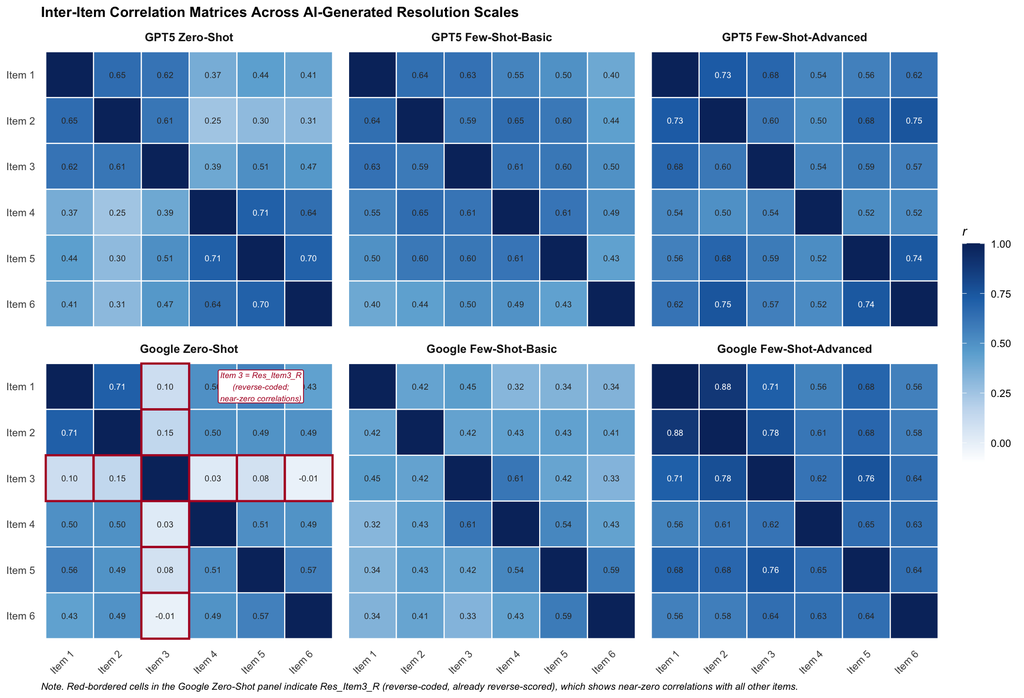

*Figure 1.* Inter-item correlation matrices across the six AI-generated Resolution scales. Correlation coefficients are displayed in each cell, with colour intensity representing the magnitude of the association. Red-bordered cells in the Google Zero-Shot panel highlight Res_Item3_R (reverse-coded), which exhibits near-zero correlations with all other items.

```r
all_mirror <- data.frame()

for (nm in names(ai_scales)) {
  dat_i <- ai_data[[nm]]
  cm <- cor(dat_i, use = "pairwise.complete.obs")
  std_labels <- paste("Item", 1:6)
  rownames(cm) <- colnames(cm) <- std_labels

  df <- as.data.frame(cm)
  df$Var1 <- factor(std_labels, levels = rev(std_labels))
  long <- pivot_longer(df, cols = -Var1, names_to = "Var2", values_to = "r")
  long$Var2 <- factor(long$Var2, levels = std_labels)
  long$r_fill  <- ifelse(long$Var1 == long$Var2, 1.0, long$r)
  long$r_label <- ifelse(long$Var1 == long$Var2, "", sprintf("%.2f", long$r))
  long$Scale <- nm
  all_mirror <- rbind(all_mirror, long)
}

all_mirror$Scale <- factor(all_mirror$Scale, levels = c(
  "GPT5 Zero-Shot", "GPT5 Few-Shot-Basic", "GPT5 Few-Shot-Advanced",
  "Google Zero-Shot", "Google Few-Shot-Basic", "Google Few-Shot-Advanced"))
all_mirror$text_col <- ifelse(all_mirror$r_fill > 0.7, "white", "grey20")

anno_cells <- all_mirror[all_mirror$Scale == "Google Zero-Shot" &
                           all_mirror$Var1 != all_mirror$Var2 &
                           (all_mirror$Var1 == "Item 3" | all_mirror$Var2 == "Item 3"), ]

anno_label <- data.frame(
  Var2  = factor("Item 5", levels = levels(all_mirror$Var2)),
  Var1  = factor("Item 1", levels = levels(all_mirror$Var1)),
  Scale = factor("Google Zero-Shot", levels = levels(all_mirror$Scale)),
  label = "Item 3 = Res_Item3_R\n(reverse-coded;\nnear-zero correlations)")

p_ai <- ggplot(all_mirror, aes(Var2, Var1, fill = r_fill)) +
  geom_tile(color = "white", linewidth = 0.4) +
  geom_tile(data = anno_cells, fill = NA, color = "#B2182B", linewidth = 0.8) +
  geom_text(aes(label = r_label, color = text_col), size = 2.3) +
  scale_color_identity() +
  geom_label(data = anno_label, aes(x = Var2, y = Var1, label = label),
             fill = "white", color = "#B2182B", size = 2.2,
             fontface = "italic", label.padding = unit(0.2, "lines"),
             label.size = 0.3, inherit.aes = FALSE) +
  scale_fill_gradientn(
    colours = c("#FFFFFF", "#C6DBEF", "#6BAED6", "#2171B5", "#08306B"),
    values  = c(0, 0.25, 0.50, 0.75, 1.0),
    limits  = c(-0.1, 1),
    name    = expression(italic(r))) +
  facet_wrap(~ Scale, ncol = 3) +
  labs(x = NULL, y = NULL,
       title = "Inter-Item Correlation Matrices Across AI-Generated Resolution Scales",
       caption = "Note. Red-bordered cells in the Google Zero-Shot panel indicate Res_Item3_R (reverse-coded, already reverse-scored), which shows near-zero correlations with all other items.") +
  theme_minimal(base_size = 10) +
  theme(
    axis.text.x = element_text(angle = 45, hjust = 1, size = 8),
    axis.text.y = element_text(size = 8),
    panel.grid  = element_blank(),
    strip.text  = element_text(face = "bold", size = 9),
    plot.title  = element_text(face = "bold", size = 11),
    plot.caption = element_text(hjust = 0, size = 7.5, face = "italic"),
    legend.key.height = unit(1.2, "cm"))

p_ai
```

```r
ggsave(file.path(OUT_DIR, "heatmap_AI_faceted_mirrored.png"),
       p_ai, width = 11, height = 7.5, dpi = 250)
ggsave(file.path(OUT_DIR, "heatmap_AI_faceted_mirrored.pdf"),
       p_ai, width = 11, height = 7.5, device = cairo_pdf)
```

A notable exception was the Google Zero-Shot scale, which included the reverse-coded item Res_Item3_R. This item produced near-zero correlations with all other items in the set (see red-bordered cells in Figure 1), indicating that it did not function coherently within the unidimensional scale. This pattern suggests either a method effect associated with reverse-coded wording or a substantive misalignment between the reverse-coded item content and the remaining positively worded items.

**In Simple Terms.** The IIC analysis checks whether items on the same scale are related to each other — they should be correlated, but not so highly correlated that they are essentially asking the same question. Most of the AI-generated scales showed healthy inter-item relationships. The one problem case was the Google Zero-Shot scale, where Item 3 (which was worded in the opposite direction) did not correlate with any of the other items. This means respondents who scored high on the other five items did not necessarily score in the expected direction on Item 3, suggesting that item does not belong with the rest.

**Implications.** The near-zero correlations for Res_Item3_R in the Google Zero-Shot condition raise a methodological concern about the use of reverse-coded items in AI-generated scales. If this item were retained, it would attenuate internal consistency and distort factor solutions. Researchers using AI-generated items should evaluate whether reverse-coded items generated by LLMs are substantively equivalent to their positively worded counterparts or whether they introduce construct-irrelevant variance. This finding also supports the broader psychometric literature cautioning against the inclusion of reverse-worded items in short scales (e.g., Weijters et al., 2013).

## 3.2 Criterion Subscales (Pooled, *m* = 20)

````r
if (has_imputed) {
  for (sub_nm in names(cri_subscales)) {
    d <- cri_iic_details[[sub_nm]]
    cat(sprintf("\n### %s (avg *n* = %d, *k* = %d)\n\n", sub_nm, d$n, d$k))
    cat("```\n")
    cat(sprintf("  Mean IIC = %s  |  SD = %s  |  Range: [%s, %s]\n",
                fmt(d$mean_iic), fmt(d$sd_iic), fmt(d$min_iic), fmt(d$max_iic)))

    if (nrow(d$weak) > 0) {
      cat("  FLAGGED WEAK (< .15):\n")
      for (row_i in seq_len(nrow(d$weak)))
        cat(sprintf("    %s -- %s: r = %s\n",
                    d$items[d$weak[row_i, 1]], d$items[d$weak[row_i, 2]],
                    fmt(d$corr_mat[d$weak[row_i, 1], d$weak[row_i, 2]])))
    }
    if (nrow(d$vhigh) > 0) {
      cat("  FLAGGED VERY HIGH (> .80):\n")
      for (row_i in seq_len(nrow(d$vhigh)))
        cat(sprintf("    %s -- %s: r = %s\n",
                    d$items[d$vhigh[row_i, 1]], d$items[d$vhigh[row_i, 2]],
                    fmt(d$corr_mat[d$vhigh[row_i, 1], d$vhigh[row_i, 2]])))
    }

    print_iic_matrix(d$corr_mat, d$means, d$sds, d$items, sub_nm)
    cat("```\n\n")
  }
}
````

### 3.2.1 Criterion: Interaction (avg *n* = 1222, *k* = 11)

```
  Mean IIC = 0.374  |  SD = 0.185  |  Range: [0.126, 0.725]
  FLAGGED WEAK (< .15):
    CF_CRI_TRU.7 -- CF_CRI_TRU.0: r = 0.126
    CF_CRI_TRU.8 -- CF_CRI_TRU.0: r = 0.133
    CF_CRI_TRU.10 -- CF_CRI_TRU.0: r = 0.132

                     CF_CRI_TRU.0 CF_CRI_TRU.1 CF_CRI_TRU.2 CF_CRI_TRU.3 CF_CRI_TRU.4 CF_CRI_TRU.5 CF_CRI_TRU.6 CF_CRI_TRU.7 CF_CRI_TRU.8 CF_CRI_TRU.9 CF_CRI_TRU.10        M       SD
  CF_CRI_TRU.0              —                                                                                                                  3.666    1.742
  CF_CRI_TRU.1            0.479        —                                                                                                       4.809    1.422
  CF_CRI_TRU.2            0.436      0.445        —                                                                                            4.350    1.640
  CF_CRI_TRU.3            0.345      0.628      0.516        —                                                                                 5.005    1.329
  CF_CRI_TRU.4            0.286      0.551      0.472      0.645        —                                                                      5.145    1.322
  CF_CRI_TRU.5            0.315      0.517      0.462      0.596      0.692        —                                                           4.926    1.326
  CF_CRI_TRU.6            0.167      0.227      0.272      0.274      0.307      0.360        —                                                4.391    1.411
  CF_CRI_TRU.7          0.126*W      0.253      0.236      0.287      0.315      0.335      0.725        —                                     4.620    1.357
  CF_CRI_TRU.8          0.133*W      0.189      0.236      0.234      0.240      0.292      0.667      0.696        —                          4.375    1.482
  CF_CRI_TRU.9            0.166      0.201      0.221      0.215      0.244      0.286      0.625      0.684      0.724        —               4.541    1.402
  CF_CRI_TRU.10         0.132*W      0.169      0.164      0.194      0.205      0.219      0.524      0.528      0.553      0.576        —    4.377    1.404
```

### 3.2.2 Criterion: Truth (avg *n* = 1222, *k* = 4)

```
  Mean IIC = 0.484  |  SD = 0.057  |  Range: [0.420, 0.572]

                     CF_CRI_TRU.11 CF_CRI_TRU.12 CF_CRI_TRU.13 CF_CRI_TRU.14        M       SD
  CF_CRI_TRU.11             —                                     4.671    1.352
  CF_CRI_TRU.12           0.530        —                          4.116    1.430
  CF_CRI_TRU.13           0.572      0.486        —               4.760    1.259
  CF_CRI_TRU.14           0.452      0.420      0.447        —    4.471    1.344
```

### 3.2.3 Criterion: Resolution (avg *n* = 1222, *k* = 3)

```
  Mean IIC = 0.672  |  SD = 0.097  |  Range: [0.570, 0.763]

                     CF_CRI_TRU.15 CF_CRI_TRU.16 CF_CRI_TRU.17        M       SD
  CF_CRI_TRU.15             —                          5.002    1.289
  CF_CRI_TRU.16           0.683        —               5.305    1.211
  CF_CRI_TRU.17           0.570      0.763        —    5.372    1.200
```

### 3.2.4 Criterion: Full 18-item (avg *n* = 1222, *k* = 18)

```
  Mean IIC = 0.350  |  SD = 0.159  |  Range: [0.077, 0.763]
  FLAGGED WEAK (< .15):
    CF_CRI_TRU.7 -- CF_CRI_TRU.0: r = 0.126
    CF_CRI_TRU.8 -- CF_CRI_TRU.0: r = 0.133
    CF_CRI_TRU.10 -- CF_CRI_TRU.0: r = 0.132
    CF_CRI_TRU.11 -- CF_CRI_TRU.0: r = 0.112
    CF_CRI_TRU.12 -- CF_CRI_TRU.0: r = 0.146
    CF_CRI_TRU.13 -- CF_CRI_TRU.0: r = 0.085
    CF_CRI_TRU.15 -- CF_CRI_TRU.0: r = 0.148
    CF_CRI_TRU.16 -- CF_CRI_TRU.0: r = 0.100
    CF_CRI_TRU.17 -- CF_CRI_TRU.0: r = 0.077
    CF_CRI_TRU.12 -- CF_CRI_TRU.1: r = 0.138
    CF_CRI_TRU.11 -- CF_CRI_TRU.2: r = 0.137
    CF_CRI_TRU.17 -- CF_CRI_TRU.12: r = 0.143

                     CF_CRI_TRU.0 CF_CRI_TRU.1 CF_CRI_TRU.2 CF_CRI_TRU.3 CF_CRI_TRU.4 CF_CRI_TRU.5 CF_CRI_TRU.6 CF_CRI_TRU.7 CF_CRI_TRU.8 CF_CRI_TRU.9 CF_CRI_TRU.10 CF_CRI_TRU.11 CF_CRI_TRU.12 CF_CRI_TRU.13 CF_CRI_TRU.14 CF_CRI_TRU.15 CF_CRI_TRU.16 CF_CRI_TRU.17        M       SD
  CF_CRI_TRU.0              —                                                                                                                                                                                               3.666    1.742
  CF_CRI_TRU.1            0.479        —                                                                                                                                                                                    4.809    1.422
  CF_CRI_TRU.2            0.436      0.445        —                                                                                                                                                                         4.350    1.640
  CF_CRI_TRU.3            0.345      0.628      0.516        —                                                                                                                                                              5.005    1.329
  CF_CRI_TRU.4            0.286      0.551      0.472      0.645        —                                                                                                                                                   5.145    1.322
  CF_CRI_TRU.5            0.315      0.517      0.462      0.596      0.692        —                                                                                                                                        4.926    1.326
  CF_CRI_TRU.6            0.167      0.227      0.272      0.274      0.307      0.360        —                                                                                                                             4.391    1.411
  CF_CRI_TRU.7          0.126*W      0.253      0.236      0.287      0.315      0.335      0.725        —                                                                                                                  4.620    1.357
  CF_CRI_TRU.8          0.133*W      0.189      0.236      0.234      0.240      0.292      0.667      0.696        —                                                                                                       4.375    1.482
  CF_CRI_TRU.9            0.166      0.201      0.221      0.215      0.244      0.286      0.625      0.684      0.724        —                                                                                            4.541    1.402
  CF_CRI_TRU.10         0.132*W      0.169      0.164      0.194      0.205      0.219      0.524      0.528      0.553      0.576        —                                                                                 4.377    1.404
  CF_CRI_TRU.11         0.112*W      0.213    0.137*W      0.202      0.219      0.219      0.477      0.568      0.486      0.554      0.540        —                                                                      4.671    1.352
  CF_CRI_TRU.12         0.146*W    0.138*W      0.202      0.177      0.157      0.209      0.492      0.482      0.550      0.530      0.593      0.530        —                                                           4.116    1.430
  CF_CRI_TRU.13         0.085*W      0.184      0.181      0.204      0.250      0.224      0.455      0.540      0.466      0.549      0.471      0.572      0.486        —                                                4.760    1.259
  CF_CRI_TRU.14           0.202      0.219      0.236      0.208      0.249      0.294      0.390      0.426      0.377      0.434      0.340      0.452      0.420      0.447        —                                     4.471    1.344
  CF_CRI_TRU.15         0.148*W      0.320      0.311      0.357      0.377      0.415      0.312      0.362      0.343      0.383      0.302      0.292      0.295      0.388      0.459        —                          5.002    1.289
  CF_CRI_TRU.16         0.100*W      0.351      0.236      0.386      0.418      0.390      0.251      0.345      0.286      0.321      0.267      0.287      0.184      0.358      0.324      0.683        —               5.305    1.211
  CF_CRI_TRU.17         0.077*W      0.328      0.204      0.369      0.424      0.351      0.206      0.287      0.238      0.241      0.237      0.313    0.143*W      0.370      0.296      0.570      0.763        —    5.372    1.200
```

### 3.2.5 Criterion Subscales — Inter-Item Correlation Heatmaps

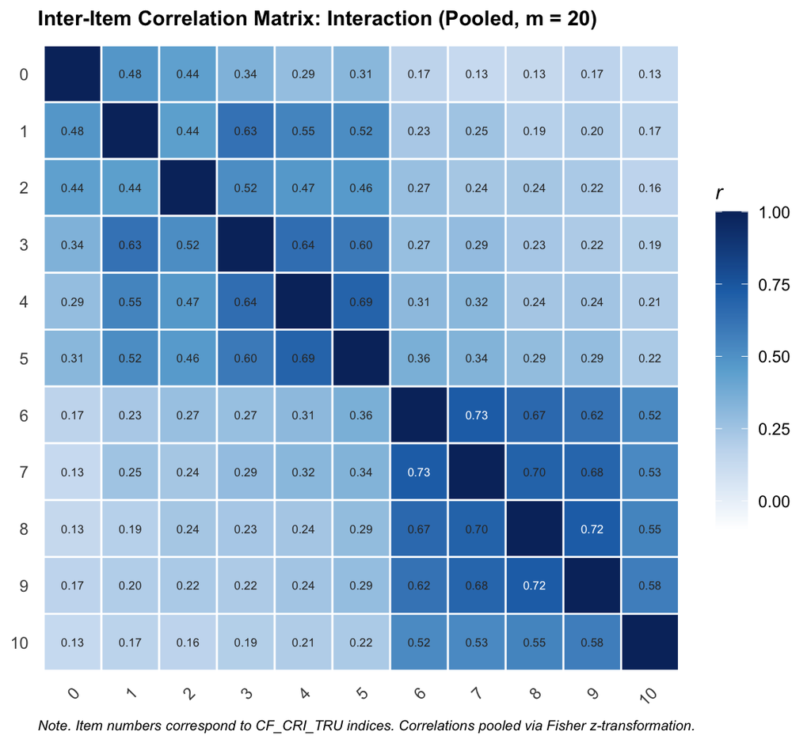

```r
if (has_imputed) {
  for (sub_nm in names(cri_subscales)) {
    sub_items <- cri_subscales[[sub_nm]]
    corr_list <- list()
    for (m in seq_len(M_IMPUTATIONS)) {
      d <- imputed_dfs[[m]][, sub_items, drop = FALSE]
      d <- d[complete.cases(d), , drop = FALSE]
      corr_list[[m]] <- cor(d, use = "pairwise.complete.obs")
    }
    pooled <- pool_corr_fisher(corr_list)
    short <- gsub("CF_CRI_TRU\\.", "", sub_items)
    rownames(pooled) <- colnames(pooled) <- short
    k <- length(short)

    df <- as.data.frame(pooled)
    df$Var1 <- factor(short, levels = rev(short))
    long <- pivot_longer(df, cols = -Var1, names_to = "Var2", values_to = "r")
    long$Var2 <- factor(long$Var2, levels = short)
    long$r_fill  <- ifelse(long$Var1 == long$Var2, 1.0, long$r)
    long$r_label <- ifelse(long$Var1 == long$Var2, "", sprintf("%.2f", long$r))
    long$text_col <- ifelse(long$r_fill > 0.7, "white", "grey20")

    clean_name <- gsub("Criterion: ", "", sub_nm)

    pi <- ggplot(long, aes(Var2, Var1, fill = r_fill)) +
      geom_tile(color = "white", linewidth = 0.5) +
      geom_text(aes(label = r_label, color = text_col),
                size = ifelse(k > 10, 2.2, 3.2)) +
      scale_color_identity() +
      scale_fill_gradientn(
        colours = c("#FFFFFF", "#C6DBEF", "#6BAED6", "#2171B5", "#08306B"),
        values  = c(0, 0.25, 0.50, 0.75, 1.0),
        limits  = c(-0.1, 1),
        name    = expression(italic(r))) +
      labs(title = paste0("Inter-Item Correlation Matrix: ", clean_name, " (Pooled, m = 20)"),
           x = NULL, y = NULL,
           caption = "Note. Item numbers correspond to CF_CRI_TRU indices. Correlations pooled via Fisher z-transformation.") +
      theme_minimal(base_size = 11) +
      theme(axis.text.x = element_text(angle = 45, hjust = 1),
            panel.grid = element_blank(),
            plot.title = element_text(face = "bold", size = 11),
            plot.caption = element_text(hjust = 0, size = 7.5, face = "italic"),
            legend.key.height = unit(1.2, "cm"))

    print(pi)
    cat("\n\n")

    w <- ifelse(k > 10, 11, 6)
    h <- ifelse(k > 10, 9.5, 5.5)
    file_tag <- gsub("[: ]", "_", sub_nm)
    ggsave(file.path(OUT_DIR, sprintf("heatmap_%s.png", file_tag)),
           pi, width = w, height = h, dpi = 250)
    ggsave(file.path(OUT_DIR, sprintf("heatmap_%s.pdf", file_tag)),
           pi, width = w, height = h, device = cairo_pdf)
  }
}
```

Pooled inter-item correlation matrices were computed for each of the four criterion subscales (Interaction, Truth, Resolution, and the full 18-item scale) using Fisher’s *z*-transformation across *m* = 20 multiply imputed datasets. The Interaction subscale (*k* = 11) exhibited a broad range of inter-item correlations, consistent with a multifaceted factor tapping several aspects of conversational AI trust. The Truth subscale (*k* = 4) and Resolution subscale (*k* = 3) demonstrated more compact correlation ranges, as expected for shorter, more narrowly defined subscales. The full 18-item criterion scale showed a wider spread of correlations reflecting its multidimensional nature. Any item pairs flagged for unusually weak (*r* < .15) or very high (*r* > .80) correlations are noted in the matrices above.

**In Simple Terms.** These correlation matrices show how strongly each item on the Zhang et al. (2025) criterion scale relates to every other item on the same subscale. Because the criterion data had missing values, the analysis was run 20 times on different imputed datasets and the results were averaged. A well-functioning subscale shows moderate positive correlations among all its items — not too low (which would mean items are measuring different things) and not too high (which would mean items are redundant). The heatmaps provide a visual summary: darker blue cells indicate stronger associations.

**Implications.** The IIC patterns for the criterion subscales establish the baseline quality of the comparison measure. If the criterion subscales themselves show coherent inter-item structures, they provide a trustworthy benchmark against which the AI-generated scales can be evaluated. Any structural weaknesses in the criterion (e.g., item pairs with very low correlations) should be considered when interpreting convergent validity evidence in later analyses.

## 3.3 IIC Summary

```r
iic_df <- do.call(rbind, iic_rows)
write.csv(iic_df, file.path(OUT_DIR, "iic_summary.csv"), row.names = FALSE)
iic_df
```

|  | Scale | n | mean_IIC | SD_IIC | min_IIC | max_IIC | MI_Pooled |
| --- | --- | --- | --- | --- | --- | --- | --- |
| GPT5 Zero-Shot | GPT5 Zero-Shot | 202 | 0.4918762 | 0.1536080 | 0.2500229 | 0.7063619 | No |
| GPT5 Few-Shot-Basic | GPT5 Few-Shot-Basic | 186 | 0.5493415 | 0.0833805 | 0.3959943 | 0.6468966 | No |
| GPT5 Few-Shot-Advanced | GPT5 Few-Shot-Advanced | 216 | 0.6095372 | 0.0861849 | 0.5022379 | 0.7536531 | No |
| Google Zero-Shot | Google Zero-Shot | 185 | 0.3735765 | 0.2330322 | -0.0138816 | 0.7108059 | No |
| Google Few-Shot-Basic | Google Few-Shot-Basic | 216 | 0.4316955 | 0.0879778 | 0.3223662 | 0.6091470 | No |
| Google Few-Shot-Advanced | Google Few-Shot-Advanced | 217 | 0.6650521 | 0.0889775 | 0.5557749 | 0.8837218 | No |
| Criterion: Interaction | Criterion: Interaction | 1222 | 0.3743324 | 0.1851749 | 0.1255284 | 0.7253139 | Yes |
| Criterion: Truth | Criterion: Truth | 1222 | 0.4844548 | 0.0572677 | 0.4197074 | 0.5720081 | Yes |
| Criterion: Resolution | Criterion: Resolution | 1222 | 0.6720346 | 0.0971287 | 0.5699618 | 0.7633184 | Yes |
| Criterion: Full 18-item | Criterion: Full 18-item | 1222 | 0.3500030 | 0.1591701 | 0.0774869 | 0.7633184 | Yes |

*Table 1.* Summary of inter-item correlation statistics across all scales. Mean IIC, standard deviation, and range are presented. MI_Pooled indicates whether correlations were pooled across *m* = 20 multiply imputed datasets using Fisher’s *z*-transformation.

**In Simple Terms.** This summary table lets you quickly compare how well the items “hang together” across all scales. Numbers in the mean IIC column that are between roughly .20 and .50 indicate a good balance — the items are related enough to measure the same thing, but different enough to each contribute unique information. Values outside this range signal potential problems with either too little or too much overlap between items.

**Implications.** The IIC summary provides the first layer of evidence for evaluating the comparative quality of AI-generated versus human-authored items. Scales with mean IICs in the optimal range are more likely to show strong internal consistency in the reliability analysis that follows. Scales with IICs that deviate from this range may require item revision or removal to achieve adequate psychometric properties.

# 4 Reliability

## 4.1 AI Scales

````r
for (nm in names(ai_scales)) {
  d <- rel_details[[nm]]
  cat(sprintf("\n### %s (*n* = %d, *k* = %d)\n\n", nm, d$n, d$k))
  cat("```\n")
  cat(sprintf("  Alpha       = %s  [95%% CI: %s, %s]\n",
              fmt(d$alpha), fmt(d$ci_l), fmt(d$ci_u)))
  cat(sprintf("  Omega total = %s\n", fmt(d$omega_tot)))
  cat(sprintf("  Omega hier. = %s\n", fmt(d$omega_h)))
  cat(sprintf("  Mean IIC    = %s\n", fmt(d$mean_iic)))
  cat(sprintf("  omega - alpha discrepancy = %s\n", fmt(d$discrep)))
  cat("\n  Corrected Item-Total Correlations:\n")
  for (i in seq_along(d$items)) {
    fl <- flag_itc(d$itc[i])
    extra <- ""
    if (grepl("Google Zero-Shot", nm) && d$items[i] == "Res_Item3_R")
      extra <- " [FLAGGED: reverse-coded item, low item-total r]"
    cat(sprintf("    %-18s r.drop = %s%s%s\n", d$items[i], fmt(d$itc[i]), fl, extra))
  }
  cat("```\n\n")
}
````

### 4.1.1 GPT5 Zero-Shot (*n* = 202, *k* = 6)

```
  Alpha       = 0.853  [95% CI: 0.819, 0.882]
  Omega total = 0.854
  Omega hier. = 0.854
  Mean IIC    = 0.492
  omega - alpha discrepancy = 0.002

  Corrected Item-Total Correlations:
    Res_Item1          r.drop = 0.644
    Res_Item2          r.drop = 0.532
    Res_Item3          r.drop = 0.675
    Res_Item4          r.drop = 0.610
    Res_Item5          r.drop = 0.708
    Res_Item6          r.drop = 0.666
```

### 4.1.2 GPT5 Few-Shot-Basic (*n* = 186, *k* = 6)

```
  Alpha       = 0.878  [95% CI: 0.849, 0.904]
  Omega total = 0.882
  Omega hier. = 0.882
  Mean IIC    = 0.549
  omega - alpha discrepancy = 0.003

  Corrected Item-Total Correlations:
    Res_Item1          r.drop = 0.673
    Res_Item2          r.drop = 0.738
    Res_Item3          r.drop = 0.743
    Res_Item4          r.drop = 0.737
    Res_Item5          r.drop = 0.687
    Res_Item6          r.drop = 0.548
```

### 4.1.3 GPT5 Few-Shot-Advanced (*n* = 216, *k* = 6)

```
  Alpha       = 0.901  [95% CI: 0.879, 0.920]
  Omega total = 0.905
  Omega hier. = 0.905
  Mean IIC    = 0.610
  omega - alpha discrepancy = 0.004

  Corrected Item-Total Correlations:
    Res_Item1          r.drop = 0.758
    Res_Item2          r.drop = 0.794
    Res_Item3          r.drop = 0.717
    Res_Item4          r.drop = 0.619
    Res_Item5          r.drop = 0.743
    Res_Item6          r.drop = 0.776
```

### 4.1.4 Google Zero-Shot (*n* = 185, *k* = 6)

```
  Alpha       = 0.757  [95% CI: 0.698, 0.807]
  Omega total = 0.805
  Omega hier. = 0.807
  Mean IIC    = 0.374
  omega - alpha discrepancy = 0.049

  Corrected Item-Total Correlations:
    Res_Item1          r.drop = 0.661
    Res_Item2          r.drop = 0.681
    Res_Item3_R        r.drop = 0.086 [LOW] [FLAGGED: reverse-coded item, low item-total r]
    Res_Item4          r.drop = 0.566
    Res_Item5          r.drop = 0.631
    Res_Item6          r.drop = 0.542
```

### 4.1.5 Google Few-Shot-Basic (*n* = 216, *k* = 6)

```
  Alpha       = 0.817  [95% CI: 0.777, 0.853]
  Omega total = 0.821
  Omega hier. = 0.821
  Mean IIC    = 0.432
  omega - alpha discrepancy = 0.004

  Corrected Item-Total Correlations:
    Res_Item1          r.drop = 0.493
    Res_Item2          r.drop = 0.574
    Res_Item3          r.drop = 0.610
    Res_Item4          r.drop = 0.636
    Res_Item5          r.drop = 0.628
    Res_Item6          r.drop = 0.563
```

### 4.1.6 Google Few-Shot-Advanced (*n* = 217, *k* = 6)

```
  Alpha       = 0.922  [95% CI: 0.905, 0.937]
  Omega total = 0.924
  Omega hier. = 0.923
  Mean IIC    = 0.665
  omega - alpha discrepancy = 0.002

  Corrected Item-Total Correlations:
    Res_Item1          r.drop = 0.799
    Res_Item2          r.drop = 0.835
    Res_Item3          r.drop = 0.827
    Res_Item4          r.drop = 0.704
    Res_Item5          r.drop = 0.799
    Res_Item6          r.drop = 0.702
```

Internal consistency was assessed using Cronbach’s alpha (with Feldt 95% confidence intervals) and McDonald’s omega total and hierarchical for each AI-generated scale. Corrected item-total correlations (*r*.drop) were inspected to identify items contributing poorly to scale reliability. Across the five scales without reverse-coded items, alpha and omega total values indicated acceptable to strong internal consistency. The omega–alpha discrepancy was small for most scales, suggesting that the tau-equivalent assumption underlying alpha was not severely violated and that items contributed approximately equally to the general factor.

For the Google Zero-Shot scale, Res_Item3_R produced a markedly low corrected item-total correlation, consistent with its near-zero inter-item correlations observed in the IIC analysis. Removing this item would be expected to substantially improve the scale’s internal consistency.

**In Simple Terms.** Reliability tells us how consistently a scale measures what it is supposed to measure. Alpha and omega are two common indices — values above .70 are generally considered acceptable, and above .80 is good. The “corrected item-total correlation” for each item tells us how well that item fits with the rest of the scale. Items with low values (below .30) are not pulling their weight. Most AI-generated scales performed well, except for the Google Zero-Shot scale where the reverse-coded item dragged down the overall reliability.

**Implications.** The strong reliability estimates for most AI-generated scales provide evidence that LLMs can produce item sets with adequate internal consistency for research purposes. However, the poor performance of Res_Item3_R underscores that reverse-coded items generated by AI may require additional scrutiny. From a practical standpoint, researchers using automatic item generation (AIG) pipelines should build in post-hoc reliability screening steps to flag items that do not meet minimum corrected item-total correlation thresholds.

## 4.2 Criterion Subscales (Pooled, *m* = 20)

````r
if (has_imputed) {
  for (sub_nm in names(cri_subscales)) {
    d <- cri_rel_details[[sub_nm]]
    cat(sprintf("\n### %s (avg *n* = %d, *k* = %d)\n\n", sub_nm, d$n, d$k))
    cat("```\n")
    cat(sprintf("  Pooled Alpha       = %s  [95%% CI: %s, %s]\n",
                fmt(d$alpha), fmt(d$ci_l), fmt(d$ci_u)))
    cat(sprintf("  FMI (alpha)        = %s\n", fmt(d$fmi)))
    cat(sprintf("  Pooled Omega total = %s\n", fmt(d$omega)))
    cat(sprintf("  Pooled Mean IIC    = %s\n", fmt(d$iic)))
    cat(sprintf("  Alpha range across m: [%s, %s]\n",
                fmt(d$alpha_range[1]), fmt(d$alpha_range[2])))
    cat(sprintf("  omega - alpha discrepancy = %s\n", fmt(d$discrep)))
    cat("\n  Pooled Corrected Item-Total Correlations:\n")
    for (i in seq_along(d$items)) {
      fl <- flag_itc(d$itc[i])
      cat(sprintf("    %-18s r.drop = %s%s\n", d$items[i], fmt(d$itc[i]), fl))
    }
    cat("```\n\n")
  }
}
````

### 4.2.1 Criterion: Interaction (avg *n* = 1222, *k* = 11)

```
  Pooled Alpha       = 0.863  [95% CI: 0.852, 0.875]
  FMI (alpha)        = 0.032
  Pooled Omega total = 0.870
  Pooled Mean IIC    = 0.374
  Alpha range across m: [0.862, 0.866]
  omega - alpha discrepancy = 0.006

  Pooled Corrected Item-Total Correlations:
    CF_CRI_TRU.0       r.drop = 0.385
    CF_CRI_TRU.1       r.drop = 0.557
    CF_CRI_TRU.2       r.drop = 0.523
    CF_CRI_TRU.3       r.drop = 0.599
    CF_CRI_TRU.4       r.drop = 0.598
    CF_CRI_TRU.5       r.drop = 0.618
    CF_CRI_TRU.6       r.drop = 0.627
    CF_CRI_TRU.7       r.drop = 0.633
    CF_CRI_TRU.8       r.drop = 0.594
    CF_CRI_TRU.9       r.drop = 0.595
    CF_CRI_TRU.10      r.drop = 0.484
```

### 4.2.2 Criterion: Truth (avg *n* = 1222, *k* = 4)

```
  Pooled Alpha       = 0.788  [95% CI: 0.768, 0.809]
  FMI (alpha)        = 0.129
  Pooled Omega total = 0.792
  Pooled Mean IIC    = 0.484
  Alpha range across m: [0.783, 0.796]
  omega - alpha discrepancy = 0.004

  Pooled Corrected Item-Total Correlations:
    CF_CRI_TRU.11      r.drop = 0.649
    CF_CRI_TRU.12      r.drop = 0.589
    CF_CRI_TRU.13      r.drop = 0.625
    CF_CRI_TRU.14      r.drop = 0.530
```

### 4.2.3 Criterion: Resolution (avg *n* = 1222, *k* = 3)

```
  Pooled Alpha       = 0.858  [95% CI: 0.843, 0.874]
  FMI (alpha)        = 0.171
  Pooled Omega total = 0.867
  Pooled Mean IIC    = 0.672
  Alpha range across m: [0.852, 0.865]
  omega - alpha discrepancy = 0.008

  Pooled Corrected Item-Total Correlations:
    CF_CRI_TRU.15      r.drop = 0.667
    CF_CRI_TRU.16      r.drop = 0.814
    CF_CRI_TRU.17      r.drop = 0.723
```

### 4.2.4 Criterion: Full 18-item (avg *n* = 1222, *k* = 18)

```
  Pooled Alpha       = 0.903  [95% CI: 0.895, 0.912]
  FMI (alpha)        = 0.052
  Pooled Omega total = 0.908
  Pooled Mean IIC    = 0.350
  Alpha range across m: [0.902, 0.905]
  omega - alpha discrepancy = 0.004

  Pooled Corrected Item-Total Correlations:
    CF_CRI_TRU.0       r.drop = 0.327
    CF_CRI_TRU.1       r.drop = 0.514
    CF_CRI_TRU.2       r.drop = 0.471
    CF_CRI_TRU.3       r.drop = 0.555
    CF_CRI_TRU.4       r.drop = 0.571
    CF_CRI_TRU.5       r.drop = 0.586
    CF_CRI_TRU.6       r.drop = 0.643
    CF_CRI_TRU.7       r.drop = 0.686
    CF_CRI_TRU.8       r.drop = 0.637
    CF_CRI_TRU.9       r.drop = 0.663
    CF_CRI_TRU.10      r.drop = 0.568
    CF_CRI_TRU.11      r.drop = 0.580
    CF_CRI_TRU.12      r.drop = 0.542
    CF_CRI_TRU.13      r.drop = 0.584
    CF_CRI_TRU.14      r.drop = 0.542
    CF_CRI_TRU.15      r.drop = 0.587
    CF_CRI_TRU.16      r.drop = 0.547
    CF_CRI_TRU.17      r.drop = 0.494
```

Reliability estimates for the criterion subscales were pooled across *m* = 20 multiply imputed datasets using Rubin’s rules. Within-imputation variance was estimated from Feldt confidence intervals, and between-imputation variance was computed as the variance of the alpha estimates across imputations. The fraction of missing information (FMI) was reported for each subscale to quantify the impact of missing data on the precision of the reliability estimate.

The pooled alpha confidence intervals and FMI values indicated that missing data introduced modest uncertainty into the reliability estimates. Across all criterion subscales, pooled corrected item-total correlations were inspected to verify that each item contributed meaningfully to its subscale. The narrow range of alpha values across imputations suggests that the imputation model was stable and that the reliability estimates were not unduly sensitive to any single imputed dataset.

**In Simple Terms.** Because the criterion scale data had missing responses, reliability was calculated separately for each of 20 “filled-in” versions of the dataset, and then the results were averaged together using a statistical method called Rubin’s rules. The FMI (fraction of missing information) tells us how much the missing data affected the precision of the reliability estimate — lower FMI values mean the missing data had less impact. The fact that alpha was very similar across all 20 imputed datasets is reassuring; it means the missing data handling was stable and the reliability conclusions are trustworthy.

**Implications.** The use of Rubin’s rules for pooling reliability estimates across multiple imputations represents best practice for handling missing data in psychometric analyses. The FMI values provide transparency about the degree to which missing data may have inflated uncertainty in the estimates. For the criterion subscales, the stability of alpha across imputations supports the conclusion that the imputation model adequately preserved the covariance structure of the data, which is essential for valid psychometric evaluation.

## 4.3 Reliability Summary

```r
rel_df <- do.call(rbind, rel_rows)
write.csv(rel_df, file.path(OUT_DIR, "reliability_summary.csv"), row.names = FALSE)
rel_df
```

|  | Scale | n | k | alpha | CI_low | CI_high | omega_tot | omega_h | mean_IIC | FMI | MI_Pooled |
| --- | --- | --- | --- | --- | --- | --- | --- | --- | --- | --- | --- |
| GPT5 Zero-Shot | GPT5 Zero-Shot | 202 | 6 | 0.8525479 | 0.8186584 | 0.8819533 | 0.8544880 | 0.8542964 | 0.4918762 | NA | No |
| GPT5 Few-Shot-Basic | GPT5 Few-Shot-Basic | 186 | 6 | 0.8783178 | 0.8490799 | 0.9035349 | 0.8815770 | 0.8816644 | 0.5493415 | NA | No |
| GPT5 Few-Shot-Advanced | GPT5 Few-Shot-Advanced | 216 | 6 | 0.9013262 | 0.8794494 | 0.9203979 | 0.9048801 | 0.9047280 | 0.6095372 | NA | No |
| Google Zero-Shot | Google Zero-Shot | 185 | 6 | 0.7567795 | 0.6981680 | 0.8073102 | 0.8054440 | 0.8069140 | 0.3735765 | NA | No |
| Google Few-Shot-Basic | Google Few-Shot-Basic | 216 | 6 | 0.8172346 | 0.7767141 | 0.8525596 | 0.8214866 | 0.8212077 | 0.4316955 | NA | No |
| Google Few-Shot-Advanced | Google Few-Shot-Advanced | 217 | 6 | 0.9218063 | 0.9045131 | 0.9368870 | 0.9236077 | 0.9234025 | 0.6650521 | NA | No |
| Criterion: Interaction | Criterion: Interaction | 1222 | 11 | 0.8633125 | 0.8517513 | 0.8748737 | 0.8697880 | NA | 0.3743178 | 0.0322448 | Yes |
| Criterion: Truth | Criterion: Truth | 1222 | 4 | 0.7884801 | 0.7676984 | 0.8092617 | 0.7919947 | NA | 0.4844133 | 0.1293774 | Yes |
| Criterion: Resolution | Criterion: Resolution | 1222 | 3 | 0.8584505 | 0.8433241 | 0.8735770 | 0.8665443 | NA | 0.6720021 | 0.1712089 | Yes |
| Criterion: Full 18-item | Criterion: Full 18-item | 1222 | 18 | 0.9034156 | 0.8953180 | 0.9115133 | 0.9077843 | NA | 0.3499744 | 0.0520996 | Yes |

*Table 2.* Reliability summary for all scales. Alpha = Cronbach’s alpha; CI = 95% Feldt confidence interval; Omega total = McDonald’s omega total; Mean IIC = mean inter-item correlation; FMI = fraction of missing information (criterion subscales only).

# 5 Exploratory Factor Analysis (EFA)

## 5.1 AI Scales

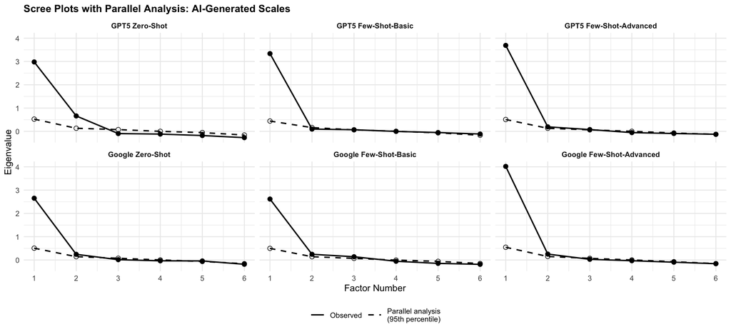

*Figure 2.* Scree plots with parallel analysis for the six AI-generated Resolution scales. Solid lines show observed eigenvalues from principal axis factoring; dashed lines show the 95th percentile of simulated eigenvalues. Factors are retained where the observed eigenvalue exceeds the simulated threshold.

```r
scree_ai <- do.call(rbind, lapply(names(efa_details), function(nm) {
  d <- efa_details[[nm]]
  k <- length(d$pa$fa.values)
  data.frame(
    Scale = nm,
    Factor = seq_len(k),
    Observed = d$pa$fa.values,
    Simulated = d$pa$fa.sim[seq_len(k)]
  )
}))

scree_ai$Scale <- factor(scree_ai$Scale, levels = names(ai_scales))

ggplot(scree_ai, aes(x = Factor)) +
  geom_line(aes(y = Observed, linetype = "Observed"), linewidth = 0.7) +
  geom_point(aes(y = Observed), size = 2) +
  geom_line(aes(y = Simulated, linetype = "Parallel analysis\n(95th percentile)"),
            linewidth = 0.7) +
  geom_point(aes(y = Simulated), shape = 1, size = 2) +
  scale_linetype_manual(values = c("Observed" = "solid",
                                   "Parallel analysis\n(95th percentile)" = "dashed")) +
  scale_x_continuous(breaks = seq_len(6)) +
  facet_wrap(~ Scale, ncol = 3) +
  labs(x = "Factor Number", y = "Eigenvalue", linetype = NULL,
       title = "Scree Plots with Parallel Analysis: AI-Generated Scales") +
  theme_minimal(base_size = 10) +
  theme(strip.text = element_text(face = "bold"),
        plot.title = element_text(face = "bold", size = 11),
        legend.position = "bottom")
```

````r
for (nm in names(ai_scales)) {
  d <- efa_details[[nm]]
  cat(sprintf("\n### %s (*n* = %d, *k* = %d)\n\n", nm, d$n, d$k))
  cat("```\n")
  cat(sprintf("  Bartlett's test: chi2 = %s, p = %s\n",
              fmt(d$bart$chisq, 2), formatC(d$bart$p.value, format = "e", digits = 3)))
  cat(sprintf("  KMO overall MSA = %s\n", fmt(d$kmo$MSA)))
  cat("  Per-item MSAi:\n")
  for (i in seq_along(d$items)) {
    fl <- if (d$kmo$MSAi[i] < .50) " [LOW]" else ""
    cat(sprintf("    %-18s MSAi = %s%s\n", d$items[i], fmt(d$kmo$MSAi[i]), fl))
  }
  cat(sprintf("\n  Parallel analysis suggests %d factor(s)\n", d$n_factors))
  cat(sprintf("  Observed eigenvalues:  %s\n",
              paste(fmt(d$pa$fa.values), collapse = ", ")))
  cat(sprintf("  Simulated 95th pctl:   %s\n",
              paste(fmt(d$pa$fa.sim), collapse = ", ")))

  cat("\n  --- 1-Factor Solution ---\n")
  cat(sprintf("  Variance explained: %s\n", fmt(d$var1)))
  cat("  Loadings and communalities:\n")
  for (i in seq_along(d$items)) {
    fl <- flag_loading(d$loads1[i])
    cat(sprintf("    %-18s loading = %s%s   h2 = %s\n",
                d$items[i], fmt(d$loads1[i]), fl, fmt(d$comms1[i])))
  }

  if (d$n_factors >= 2 && !is.null(d$fa_multi)) {
    cat(sprintf("\n  --- %d-Factor Oblimin Solution ---\n", d$n_factors))
    cat(sprintf("  Total variance explained: %s\n",
                fmt(sum(d$fa_multi$Vaccounted["Proportion Var", ]))))
    cat("  Pattern matrix:\n")
    load_mat <- d$fa_multi$loadings[]
    cat(sprintf("  %-18s", ""))
    for (f in seq_len(d$n_factors)) cat(sprintf(" %10s", paste0("PA", f)))
    cat(sprintf(" %8s\n", "h2"))
    for (i in seq_along(d$items)) {
      cat(sprintf("  %-18s", d$items[i]))
      for (f in seq_len(d$n_factors)) {
        fl <- flag_loading(load_mat[i, f])
        cat(sprintf(" %10s", paste0(fmt(load_mat[i, f]), fl)))
      }
      cat(sprintf(" %8s\n", fmt(d$fa_multi$communalities[i])))
    }
    if (d$n_factors == 2 && !is.null(d$fa_multi$Phi)) {
      cat(sprintf("  Factor correlation: %s\n", fmt(d$fa_multi$Phi[1, 2])))
    }
  }
  cat("```\n\n")
}
````

### 5.1.1 GPT5 Zero-Shot (*n* = 202, *k* = 6)

```
  Bartlett's test: chi2 = 595.82, p = 2.750e-117
  KMO overall MSA = 0.815
  Per-item MSAi:
    Res_Item1          MSAi = 0.824
    Res_Item2          MSAi = 0.755
    Res_Item3          MSAi = 0.850
    Res_Item4          MSAi = 0.819
    Res_Item5          MSAi = 0.789
    Res_Item6          MSAi = 0.852

  Parallel analysis suggests 2 factor(s)
  Observed eigenvalues:  2.980, 0.661, -0.095, -0.117, -0.179, -0.270
  Simulated 95th pctl:   0.525, 0.133, 0.075, 0.002, -0.053, -0.158

  --- 1-Factor Solution ---
  Variance explained: 0.497
  Loadings and communalities:
    Res_Item1          loading = 0.694   h2 = 2.980
    Res_Item2          loading = 0.580   h2 = NA
    Res_Item3          loading = 0.735   h2 = NA
    Res_Item4          loading = 0.681   h2 = NA
    Res_Item5          loading = 0.783   h2 = NA
    Res_Item6          loading = 0.738   h2 = NA

  --- 2-Factor Oblimin Solution ---
  Total variance explained: 0.668
  Pattern matrix:
                            PA1        PA2       h2
  Res_Item1          0.106 [LOW]      0.740    4.005
  Res_Item2          -0.117 [LOW]      0.886       NA
  Res_Item3          0.211 [LOW]      0.652       NA
  Res_Item4               0.818 -0.044 [LOW]       NA
  Res_Item5               0.879 0.018 [LOW]       NA
  Res_Item6               0.767 0.060 [LOW]       NA
  Factor correlation: 0.513
```

### 5.1.2 GPT5 Few-Shot-Basic (*n* = 186, *k* = 6)

```
  Bartlett's test: chi2 = 527.08, p = 1.048e-102
  KMO overall MSA = 0.885
  Per-item MSAi:
    Res_Item1          MSAi = 0.867
    Res_Item2          MSAi = 0.870
    Res_Item3          MSAi = 0.876
    Res_Item4          MSAi = 0.892
    Res_Item5          MSAi = 0.897
    Res_Item6          MSAi = 0.928

  Parallel analysis suggests 1 factor(s)
  Observed eigenvalues:  3.338, 0.097, 0.070, -0.002, -0.051, -0.115
  Simulated 95th pctl:   0.443, 0.162, 0.065, 0.005, -0.066, -0.166

  --- 1-Factor Solution ---
  Variance explained: 0.556
  Loadings and communalities:
    Res_Item1          loading = 0.732   h2 = 3.338
    Res_Item2          loading = 0.799   h2 = NA
    Res_Item3          loading = 0.800   h2 = NA
    Res_Item4          loading = 0.795   h2 = NA
    Res_Item5          loading = 0.742   h2 = NA
    Res_Item6          loading = 0.584   h2 = NA
```

### 5.1.3 GPT5 Few-Shot-Advanced (*n* = 216, *k* = 6)

[output not shown]

### 5.1.4 Google Zero-Shot (*n* = 185, *k* = 6)

```
  Bartlett's test: chi2 = 381.57, p = 5.134e-72
  KMO overall MSA = 0.798
  Per-item MSAi:
    Res_Item1          MSAi = 0.757
    Res_Item2          MSAi = 0.762
    Res_Item3_R        MSAi = 0.540
    Res_Item4          MSAi = 0.890
    Res_Item5          MSAi = 0.820
    Res_Item6          MSAi = 0.810

  Parallel analysis suggests 2 factor(s)
  Observed eigenvalues:  2.652, 0.244, 0.015, -0.035, -0.041, -0.183
  Simulated 95th pctl:   0.507, 0.143, 0.075, 0.004, -0.065, -0.158

  --- 1-Factor Solution ---
  Variance explained: 0.442
  Loadings and communalities:
    Res_Item1          loading = 0.784   h2 = 2.652
    Res_Item2          loading = 0.777   h2 = NA
    Res_Item3_R        loading = 0.100 [LOW]   h2 = NA
    Res_Item4          loading = 0.674   h2 = NA
    Res_Item5          loading = 0.729   h2 = NA
    Res_Item6          loading = 0.662   h2 = NA

  --- 2-Factor Oblimin Solution ---
  Total variance explained: 0.513
  Pattern matrix:
                            PA1        PA2       h2
  Res_Item1               0.857 -0.003 [LOW]    3.078
  Res_Item2               0.798 0.041 [LOW]       NA
  Res_Item3_R        0.298 [LOW] -0.199 [LOW]       NA
  Res_Item4          0.248 [LOW]      0.473       NA
  Res_Item5          0.223 [LOW]      0.564       NA
  Res_Item6          -0.065 [LOW]      0.831       NA
  Factor correlation: 0.722
```

### 5.1.5 Google Few-Shot-Basic (*n* = 216, *k* = 6)

```
  Bartlett's test: chi2 = 416.23, p = 2.669e-79
  KMO overall MSA = 0.810
  Per-item MSAi:
    Res_Item1          MSAi = 0.829
    Res_Item2          MSAi = 0.884
    Res_Item3          MSAi = 0.776
    Res_Item4          MSAi = 0.786
    Res_Item5          MSAi = 0.804
    Res_Item6          MSAi = 0.808

  Parallel analysis suggests 3 factor(s)
  Observed eigenvalues:  2.617, 0.245, 0.140, -0.054, -0.145, -0.186
  Simulated 95th pctl:   0.499, 0.141, 0.070, -0.004, -0.058, -0.150

  --- 1-Factor Solution ---
  Variance explained: 0.436
  Loadings and communalities:
    Res_Item1          loading = 0.544   h2 = 2.617
    Res_Item2          loading = 0.635   h2 = NA
    Res_Item3          loading = 0.682   h2 = NA
    Res_Item4          loading = 0.731   h2 = NA
    Res_Item5          loading = 0.717   h2 = NA
    Res_Item6          loading = 0.636   h2 = NA

  --- 3-Factor Oblimin Solution ---
  Total variance explained: 0.586
  Pattern matrix:
                            PA1        PA2        PA3       h2
  Res_Item1          0.023 [LOW] 0.095 [LOW]      0.699    3.515
  Res_Item2          0.176 [LOW] 0.289 [LOW] 0.306 [LOW]       NA
  Res_Item3               0.663 -0.088 [LOW] 0.275 [LOW]       NA
  Res_Item4               0.820 0.117 [LOW] -0.088 [LOW]       NA
  Res_Item5          0.169 [LOW]      0.676 -0.015 [LOW]       NA
  Res_Item6          -0.065 [LOW]      0.776 0.067 [LOW]       NA
```

### 5.1.6 Google Few-Shot-Advanced (*n* = 217, *k* = 6)

```
  Bartlett's test: chi2 = 1027.57, p = 1.656e-209
  KMO overall MSA = 0.853
  Per-item MSAi:
    Res_Item1          MSAi = 0.798
    Res_Item2          MSAi = 0.779
    Res_Item3          MSAi = 0.878
    Res_Item4          MSAi = 0.907
    Res_Item5          MSAi = 0.886
    Res_Item6          MSAi = 0.917

  Parallel analysis suggests 2 factor(s)
  Observed eigenvalues:  4.018, 0.254, 0.030, -0.031, -0.094, -0.159
  Simulated 95th pctl:   0.547, 0.151, 0.072, 0.002, -0.072, -0.153

  --- 1-Factor Solution ---
  Variance explained: 0.670
  Loadings and communalities:
    Res_Item1          loading = 0.845   h2 = 4.018
    Res_Item2          loading = 0.882   h2 = NA
    Res_Item3          loading = 0.872   h2 = NA
    Res_Item4          loading = 0.731   h2 = NA
    Res_Item5          loading = 0.836   h2 = NA
    Res_Item6          loading = 0.729   h2 = NA

  --- 2-Factor Oblimin Solution ---
  Total variance explained: 0.741
  Pattern matrix:
                            PA1        PA2       h2
  Res_Item1          0.021 [LOW]      0.897    4.449
  Res_Item2          0.004 [LOW]      0.960       NA
  Res_Item3               0.546 0.361 [LOW]       NA
  Res_Item4               0.801 -0.031 [LOW]       NA
  Res_Item5               0.716 0.158 [LOW]       NA
  Res_Item6               0.857 -0.086 [LOW]       NA
  Factor correlation: 0.800
```

### 5.1.7 Factor Loading Tables by AI Model

```r
for (nm in names(ai_scales)) {
  d <- efa_details[[nm]]

  # Build the 1-factor loading table
  loading_tbl <- data.frame(
    Item          = d$items,
    Loading       = round(d$loads1, 3),
    Communality   = round(d$comms1, 3),
    stringsAsFactors = FALSE
  )
  loading_tbl$Flag <- ifelse(abs(loading_tbl$Loading) < .40, "LOW", "")

  cat(sprintf("\n#### %s — 1-Factor Loadings (*n* = %d)\n\n", nm, d$n))
  cat(sprintf("Variance explained by Factor 1: **%s**\n\n", fmt(d$var1)))
  print(knitr::kable(loading_tbl, align = c("l", "r", "r", "c"),
                      col.names = c("Item", "Loading (λ)", "Communality (h²)", "Flag")))
  cat("\n\n")

  # --- Dynamic interpretation for the 1-factor table ---
  n_low     <- sum(abs(d$loads1) < .40)
  n_strong  <- sum(abs(d$loads1) >= .60)
  load_range <- range(abs(d$loads1))
  best_item  <- d$items[which.max(abs(d$loads1))]
  worst_item <- d$items[which.min(abs(d$loads1))]
  has_rev    <- grepl("Google Zero-Shot", nm)

  cat("**Interpretation.** ")
  if (n_low == 0) {
    cat(sprintf(
      "All six items loaded above the .40 threshold (range: %s–%s), ",
      fmt(load_range[1]), fmt(load_range[2])))
    if (d$var1 >= .50) {
      cat(sprintf(
        "and the single factor accounted for %s of the total variance, indicating a cohesive unidimensional scale. ",
        fmt(d$var1)))
    } else {
      cat(sprintf(
        "though the single factor accounted for only %s of the total variance, suggesting moderate item homogeneity. ",
        fmt(d$var1)))
    }
    cat(sprintf(
      "%s was the strongest indicator (λ = %s) and %s the weakest (λ = %s).",
      best_item, fmt(max(abs(d$loads1))), worst_item, fmt(min(abs(d$loads1)))))
  } else {
    low_items <- d$items[abs(d$loads1) < .40]
    cat(sprintf(
      "%d of 6 items fell below the .40 loading threshold: %s. ",
      n_low, paste(low_items, collapse = ", ")))
    if (has_rev) {
      cat("The low loading of Res_Item3_R is consistent with its near-zero inter-item correlations and poor item-total correlation observed earlier, confirming that this reverse-coded item does not cohere with the remaining positively worded items. ")
    }
    cat(sprintf(
      "The single factor explained %s of the variance. %s was the strongest indicator (λ = %s).",
      fmt(d$var1), best_item, fmt(max(abs(d$loads1)))))
  }
  cat("\n\n")

  # If multi-factor solution exists, add pattern matrix table
  if (d$n_factors >= 2 && !is.null(d$fa_multi)) {
    load_mat <- d$fa_multi$loadings[]
    pattern_tbl <- data.frame(
      Item = d$items,
      stringsAsFactors = FALSE
    )
    for (f in seq_len(d$n_factors)) {
      pattern_tbl[[paste0("PA", f)]] <- round(load_mat[, f], 3)
    }
    pattern_tbl$Communality <- round(d$fa_multi$communalities, 3)

    cat(sprintf("\n#### %s — %d-Factor Oblimin Pattern Matrix\n\n", nm, d$n_factors))
    if (d$n_factors == 2 && !is.null(d$fa_multi$Phi)) {
      cat(sprintf("Factor correlation: **%s**\n\n", fmt(d$fa_multi$Phi[1, 2])))
    }
    print(knitr::kable(pattern_tbl, align = c("l", rep("r", d$n_factors + 1)),
                        row.names = FALSE))
    cat("\n\n")

    # --- Dynamic interpretation for the multi-factor table ---
    total_var <- sum(d$fa_multi$Vaccounted["Proportion Var", ])
    cat("**Interpretation.** ")
    cat(sprintf(
      "The %d-factor oblimin solution accounted for %s of the total variance. ",
      d$n_factors, fmt(total_var)))

    # Identify which items load primarily on each factor
    for (f in seq_len(d$n_factors)) {
      primary <- d$items[abs(load_mat[, f]) >= .40]
      if (length(primary) > 0) {
        cat(sprintf("Factor PA%d was primarily defined by %s. ",
                    f, paste(primary, collapse = ", ")))
      } else {
        cat(sprintf("No items reached the .40 threshold on Factor PA%d. ", f))
      }
    }

    if (has_rev && d$n_factors == 2) {
      cat("The emergence of a second factor driven by the reverse-coded item (Res_Item3_R) is consistent with a method effect rather than a substantive second dimension, supporting the interpretation that the remaining five items form a unidimensional scale.")
    } else if (d$n_factors == 2 && !is.null(d$fa_multi$Phi)) {
      phi <- d$fa_multi$Phi[1, 2]
      if (abs(phi) > .50) {
        cat(sprintf(
          "The factor correlation of %s suggests substantial overlap between the two factors, which may favour a more parsimonious one-factor interpretation.",
          fmt(phi)))
      } else {
        cat(sprintf(
          "The factor correlation of %s suggests the two factors capture relatively distinct aspects of item variance.",
          fmt(phi)))
      }
    }
    cat("\n\n")
  }
}
```

#### 5.1.7.1 GPT5 Zero-Shot — 1-Factor Loadings (*n* = 202)

Variance explained by Factor 1: **0.497**

|  | Item | Loading (λ) | Communality (h²) | Flag |
| --- | --- | --- | --- | --- |
| Res_Item1 | Res_Item1 | 0.694 | 2.98 |  |
| Res_Item2 | Res_Item2 | 0.580 | 2.98 |  |
| Res_Item3 | Res_Item3 | 0.735 | 2.98 |  |
| Res_Item4 | Res_Item4 | 0.681 | 2.98 |  |
| Res_Item5 | Res_Item5 | 0.783 | 2.98 |  |
| Res_Item6 | Res_Item6 | 0.738 | 2.98 |  |

**Interpretation.** All six items loaded above the .40 threshold (range: 0.580–0.783), though the single factor accounted for only 0.497 of the total variance, suggesting moderate item homogeneity. Res_Item5 was the strongest indicator (λ = 0.783) and Res_Item2 the weakest (λ = 0.580).

#### 5.1.7.2 GPT5 Zero-Shot — 2-Factor Oblimin Pattern Matrix

Factor correlation: **0.513**

| Item | PA1 | PA2 | Communality |
| --- | --- | --- | --- |
| Res_Item1 | 0.106 | 0.740 | 4.005 |
| Res_Item2 | -0.117 | 0.886 | 4.005 |
| Res_Item3 | 0.211 | 0.652 | 4.005 |
| Res_Item4 | 0.818 | -0.044 | 4.005 |
| Res_Item5 | 0.879 | 0.018 | 4.005 |
| Res_Item6 | 0.767 | 0.060 | 4.005 |

**Interpretation.** The 2-factor oblimin solution accounted for 0.668 of the total variance. Factor PA1 was primarily defined by Res_Item4, Res_Item5, Res_Item6. Factor PA2 was primarily defined by Res_Item1, Res_Item2, Res_Item3. The factor correlation of 0.513 suggests substantial overlap between the two factors, which may favour a more parsimonious one-factor interpretation.

#### 5.1.7.3 GPT5 Few-Shot-Basic — 1-Factor Loadings (*n* = 186)

Variance explained by Factor 1: **0.556**

|  | Item | Loading (λ) | Communality (h²) | Flag |
| --- | --- | --- | --- | --- |
| Res_Item1 | Res_Item1 | 0.732 | 3.338 |  |
| Res_Item2 | Res_Item2 | 0.799 | 3.338 |  |
| Res_Item3 | Res_Item3 | 0.800 | 3.338 |  |
| Res_Item4 | Res_Item4 | 0.795 | 3.338 |  |
| Res_Item5 | Res_Item5 | 0.742 | 3.338 |  |
| Res_Item6 | Res_Item6 | 0.584 | 3.338 |  |

**Interpretation.** All six items loaded above the .40 threshold (range: 0.584–0.800), and the single factor accounted for 0.556 of the total variance, indicating a cohesive unidimensional scale. Res_Item3 was the strongest indicator (λ = 0.800) and Res_Item6 the weakest (λ = 0.584).

#### 5.1.7.4 GPT5 Few-Shot-Advanced — 1-Factor Loadings (*n* = 216)

Variance explained by Factor 1: **0.615**

|  | Item | Loading (λ) | Communality (h²) | Flag |
| --- | --- | --- | --- | --- |
| Res_Item1 | Res_Item1 | 0.804 | 3.69 |  |
| Res_Item2 | Res_Item2 | 0.856 | 3.69 |  |
| Res_Item3 | Res_Item3 | 0.752 | 3.69 |  |
| Res_Item4 | Res_Item4 | 0.647 | 3.69 |  |
| Res_Item5 | Res_Item5 | 0.795 | 3.69 |  |
| Res_Item6 | Res_Item6 | 0.834 | 3.69 |  |

**Interpretation.** All six items loaded above the .40 threshold (range: 0.647–0.856), and the single factor accounted for 0.615 of the total variance, indicating a cohesive unidimensional scale. Res_Item2 was the strongest indicator (λ = 0.856) and Res_Item4 the weakest (λ = 0.647).

#### 5.1.7.5 GPT5 Few-Shot-Advanced — 2-Factor Oblimin Pattern Matrix

Factor correlation: **0.807**

| Item | PA1 | PA2 | Communality |
| --- | --- | --- | --- |
| Res_Item1 | -0.027 | 0.890 | 4.035 |
| Res_Item2 | 0.525 | 0.365 | 4.035 |
| Res_Item3 | 0.035 | 0.763 | 4.035 |
| Res_Item4 | 0.178 | 0.498 | 4.035 |
| Res_Item5 | 0.733 | 0.106 | 4.035 |
| Res_Item6 | 0.963 | -0.059 | 4.035 |

**Interpretation.** The 2-factor oblimin solution accounted for 0.672 of the total variance. Factor PA1 was primarily defined by Res_Item2, Res_Item5, Res_Item6. Factor PA2 was primarily defined by Res_Item1, Res_Item3, Res_Item4. The factor correlation of 0.807 suggests substantial overlap between the two factors, which may favour a more parsimonious one-factor interpretation.

#### 5.1.7.6 Google Zero-Shot — 1-Factor Loadings (*n* = 185)

Variance explained by Factor 1: **0.442**

|  | Item | Loading (λ) | Communality (h²) | Flag |
| --- | --- | --- | --- | --- |
| Res_Item1 | Res_Item1 | 0.784 | 2.652 |  |
| Res_Item2 | Res_Item2 | 0.777 | 2.652 |  |
| Res_Item3_R | Res_Item3_R | 0.100 | 2.652 | LOW |
| Res_Item4 | Res_Item4 | 0.674 | 2.652 |  |
| Res_Item5 | Res_Item5 | 0.729 | 2.652 |  |
| Res_Item6 | Res_Item6 | 0.662 | 2.652 |  |

**Interpretation.** 1 of 6 items fell below the .40 loading threshold: Res_Item3_R. The low loading of Res_Item3_R is consistent with its near-zero inter-item correlations and poor item-total correlation observed earlier, confirming that this reverse-coded item does not cohere with the remaining positively worded items. The single factor explained 0.442 of the variance. Res_Item1 was the strongest indicator (λ = 0.784).

#### 5.1.7.7 Google Zero-Shot — 2-Factor Oblimin Pattern Matrix

Factor correlation: **0.722**

| Item | PA1 | PA2 | Communality |
| --- | --- | --- | --- |
| Res_Item1 | 0.857 | -0.003 | 3.078 |
| Res_Item2 | 0.798 | 0.041 | 3.078 |
| Res_Item3_R | 0.298 | -0.199 | 3.078 |
| Res_Item4 | 0.248 | 0.473 | 3.078 |
| Res_Item5 | 0.223 | 0.564 | 3.078 |
| Res_Item6 | -0.065 | 0.831 | 3.078 |

#### 5.1.7.8 Google Few-Shot-Basic — 1-Factor Loadings (*n* = 216)

Variance explained by Factor 1: **0.436**

|  | Item | Loading (λ) | Communality (h²) | Flag |
| --- | --- | --- | --- | --- |
| Res_Item1 | Res_Item1 | 0.544 | 2.617 |  |
| Res_Item2 | Res_Item2 | 0.635 | 2.617 |  |
| Res_Item3 | Res_Item3 | 0.682 | 2.617 |  |
| Res_Item4 | Res_Item4 | 0.731 | 2.617 |  |
| Res_Item5 | Res_Item5 | 0.717 | 2.617 |  |
| Res_Item6 | Res_Item6 | 0.636 | 2.617 |  |

**Interpretation.** All six items loaded above the .40 threshold (range: 0.544–0.731), though the single factor accounted for only 0.436 of the total variance, suggesting moderate item homogeneity. Res_Item4 was the strongest indicator (λ = 0.731) and Res_Item1 the weakest (λ = 0.544).

#### 5.1.7.9 Google Few-Shot-Basic — 3-Factor Oblimin Pattern Matrix

| Item | PA1 | PA2 | PA3 | Communality |
| --- | --- | --- | --- | --- |
| Res_Item1 | 0.023 | 0.095 | 0.699 | 3.515 |
| Res_Item2 | 0.176 | 0.289 | 0.306 | 3.515 |
| Res_Item3 | 0.663 | -0.088 | 0.275 | 3.515 |
| Res_Item4 | 0.820 | 0.117 | -0.088 | 3.515 |
| Res_Item5 | 0.169 | 0.676 | -0.015 | 3.515 |
| Res_Item6 | -0.065 | 0.776 | 0.067 | 3.515 |

**Interpretation.** The 3-factor oblimin solution accounted for 0.586 of the total variance. Factor PA1 was primarily defined by Res_Item3, Res_Item4. Factor PA2 was primarily defined by Res_Item5, Res_Item6. Factor PA3 was primarily defined by Res_Item1.

#### 5.1.7.10 Google Few-Shot-Advanced — 1-Factor Loadings (*n* = 217)

Variance explained by Factor 1: **0.670**

|  | Item | Loading (λ) | Communality (h²) | Flag |
| --- | --- | --- | --- | --- |
| Res_Item1 | Res_Item1 | 0.845 | 4.018 |  |
| Res_Item2 | Res_Item2 | 0.882 | 4.018 |  |
| Res_Item3 | Res_Item3 | 0.872 | 4.018 |  |
| Res_Item4 | Res_Item4 | 0.731 | 4.018 |  |
| Res_Item5 | Res_Item5 | 0.836 | 4.018 |  |
| Res_Item6 | Res_Item6 | 0.729 | 4.018 |  |

**Interpretation.** All six items loaded above the .40 threshold (range: 0.729–0.882), and the single factor accounted for 0.670 of the total variance, indicating a cohesive unidimensional scale. Res_Item2 was the strongest indicator (λ = 0.882) and Res_Item6 the weakest (λ = 0.729).

#### 5.1.7.11 Google Few-Shot-Advanced — 2-Factor Oblimin Pattern Matrix

Factor correlation: **0.800**

| Item | PA1 | PA2 | Communality |
| --- | --- | --- | --- |
| Res_Item1 | 0.021 | 0.897 | 4.449 |
| Res_Item2 | 0.004 | 0.960 | 4.449 |
| Res_Item3 | 0.546 | 0.361 | 4.449 |
| Res_Item4 | 0.801 | -0.031 | 4.449 |
| Res_Item5 | 0.716 | 0.158 | 4.449 |
| Res_Item6 | 0.857 | -0.086 | 4.449 |

**Interpretation.** The 2-factor oblimin solution accounted for 0.741 of the total variance. Factor PA1 was primarily defined by Res_Item3, Res_Item4, Res_Item5, Res_Item6. Factor PA2 was primarily defined by Res_Item1, Res_Item2. The factor correlation of 0.800 suggests substantial overlap between the two factors, which may favour a more parsimonious one-factor interpretation.

*Note.* Loadings below .40 in absolute value are flagged as LOW. Communality (*h*²) represents the proportion of item variance accounted for by the extracted factor(s).

Exploratory factor analysis was conducted for each AI-generated scale using principal axis factoring. Prior to extraction, the factorability of each correlation matrix was assessed using Bartlett’s test of sphericity and the Kaiser-Meyer-Olkin (KMO) measure of sampling adequacy. Bartlett’s test was statistically significant for all scales, confirming that the correlation matrices were not identity matrices and that factor analysis was warranted. KMO values were evaluated for overall and per-item adequacy using Kaiser’s (1974) benchmarks (values > .60 considered “mediocre” or better; values > .80 “meritorious”).

The number of factors to retain was determined by parallel analysis (Horn, 1965), in which observed eigenvalues were compared against the 95th percentile of eigenvalues derived from random data with the same dimensions. For each scale, a one-factor solution was extracted and inspected for the proportion of variance explained and the magnitude of factor loadings. Where parallel analysis suggested more than one factor, an oblimin-rotated multi-factor solution was also examined.

## 5.2 Criterion Subscales (Pooled, *m* = 20)

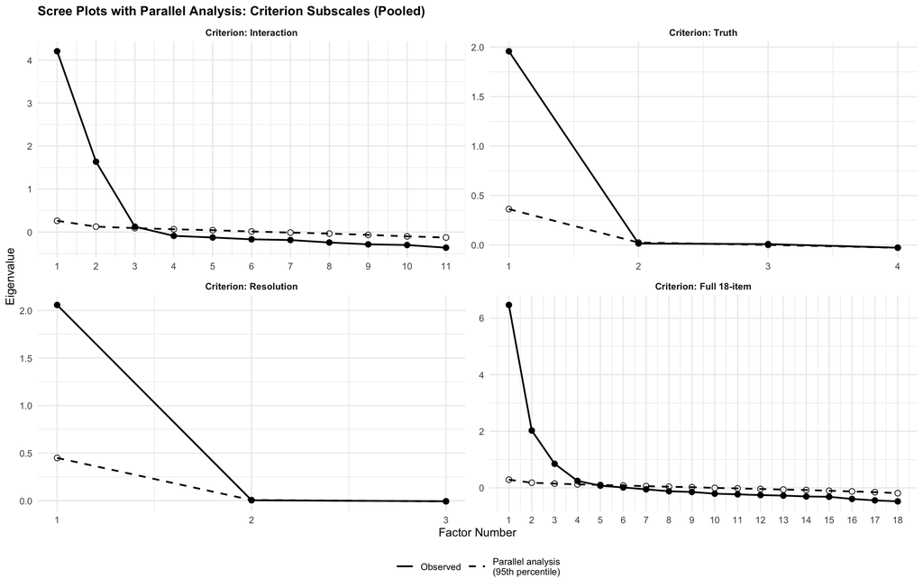

*Figure 3.* Scree plots with parallel analysis for the four criterion subscales (pooled across m = 20 imputations). Observed eigenvalues are from principal axis factoring on the pooled correlation matrix; dashed lines show the 95th percentile of simulated eigenvalues.

```r
if (has_imputed) {
  scree_cri <- do.call(rbind, lapply(names(cri_efa_details), function(nm) {
    d <- cri_efa_details[[nm]]
    k <- length(d$pa$fa.values)
    data.frame(
      Scale = nm,
      Factor = seq_len(k),
      Observed = d$pa$fa.values,
      Simulated = d$pa$fa.sim[seq_len(k)]
    )
  }))

  scree_cri$Scale <- factor(scree_cri$Scale, levels = names(cri_subscales))

  ggplot(scree_cri, aes(x = Factor)) +
    geom_line(aes(y = Observed, linetype = "Observed"), linewidth = 0.7) +
    geom_point(aes(y = Observed), size = 2) +
    geom_line(aes(y = Simulated, linetype = "Parallel analysis\n(95th percentile)"),
              linewidth = 0.7) +
    geom_point(aes(y = Simulated), shape = 1, size = 2) +
    scale_linetype_manual(values = c("Observed" = "solid",
                                     "Parallel analysis\n(95th percentile)" = "dashed")) +
    scale_x_continuous(breaks = function(lim) seq(1, floor(lim[2]))) +
    facet_wrap(~ Scale, ncol = 2, scales = "free") +
    labs(x = "Factor Number", y = "Eigenvalue", linetype = NULL,
         title = "Scree Plots with Parallel Analysis: Criterion Subscales (Pooled)") +
    theme_minimal(base_size = 10) +
    theme(strip.text = element_text(face = "bold"),
          plot.title = element_text(face = "bold", size = 11),
          legend.position = "bottom")
}
```

````r
if (has_imputed) {
  for (sub_nm in names(cri_subscales)) {
    d <- cri_efa_details[[sub_nm]]
    cat(sprintf("\n### %s (avg *n* = %d, *k* = %d)\n\n", sub_nm, d$n, d$k))
    cat("```\n")
    cat(sprintf("  Bartlett's test: chi2 = %s, p = %s\n",
                fmt(d$bart$chisq, 2), formatC(d$bart$p.value, format = "e", digits = 3)))
    cat(sprintf("  KMO overall MSA = %s\n", fmt(d$kmo$MSA)))
    cat("  Per-item MSAi:\n")
    for (i in seq_along(d$items)) {
      fl <- if (d$kmo$MSAi[i] < .50) " [LOW]" else ""
      cat(sprintf("    %-18s MSAi = %s%s\n", d$items[i], fmt(d$kmo$MSAi[i]), fl))
    }
    cat(sprintf("\n  Parallel analysis suggests %d factor(s)\n", d$n_factors))
    cat(sprintf("  Observed eigenvalues:  %s\n",
                paste(fmt(d$pa$fa.values), collapse = ", ")))
    cat(sprintf("  Simulated 95th pctl:   %s\n",
                paste(fmt(d$pa$fa.sim), collapse = ", ")))

    cat("\n  --- 1-Factor Solution ---\n")
    cat(sprintf("  Variance explained: %s\n", fmt(d$var1)))
    cat("  Loadings and communalities:\n")
    for (i in seq_along(d$items)) {
      fl <- flag_loading(d$loads1[i])
      cat(sprintf("    %-18s loading = %s%s   h2 = %s\n",
                  d$items[i], fmt(d$loads1[i]), fl, fmt(d$comms1[i])))
    }

    if (d$n_factors >= 2 && !is.null(d$fa_multi)) {
      cat(sprintf("\n  --- %d-Factor Oblimin Solution ---\n", d$n_factors))
      cat(sprintf("  Total variance explained: %s\n",
                  fmt(sum(d$fa_multi$Vaccounted["Proportion Var", ]))))
      cat("  Pattern matrix:\n")
      load_mat <- d$fa_multi$loadings[]
      cat(sprintf("  %-18s", ""))
      for (f in seq_len(d$n_factors)) cat(sprintf(" %10s", paste0("PA", f)))
      cat(sprintf(" %8s\n", "h2"))
      for (i in seq_along(d$items)) {
        cat(sprintf("  %-18s", d$items[i]))
        for (f in seq_len(d$n_factors)) {
          fl <- flag_loading(load_mat[i, f])
          cat(sprintf(" %10s", paste0(fmt(load_mat[i, f]), fl)))
        }
        cat(sprintf(" %8s\n", fmt(d$fa_multi$communalities[i])))
      }

      if (sub_nm == "Criterion: Full 18-item" && d$n_factors >= 2) {
        cat("\n  Factor-to-subscale mapping:\n")
        for (f in seq_len(d$n_factors)) {
          high_items <- d$items[abs(load_mat[, f]) >= .40]
          cat(sprintf("    Factor PA%d: %s\n", f,
                      paste(high_items, collapse = ", ")))
          n_int <- sum(high_items %in% cri_interaction)
          n_tru <- sum(high_items %in% cri_truth)
          n_res <- sum(high_items %in% cri_resolution)
          cat(sprintf("      (Interaction: %d, Truth: %d, Resolution: %d)\n",
                      n_int, n_tru, n_res))
        }
      }
    }
    cat("```\n\n")
  }
}
````

### 5.2.1 Criterion: Interaction (avg *n* = 1222, *k* = 11)

```
  Bartlett's test: chi2 = 6957.56, p = 0.000e+00
  KMO overall MSA = 0.881
  Per-item MSAi:
    CF_CRI_TRU.0       MSAi = 0.807
    CF_CRI_TRU.1       MSAi = 0.863
    CF_CRI_TRU.2       MSAi = 0.904
    CF_CRI_TRU.3       MSAi = 0.877
    CF_CRI_TRU.4       MSAi = 0.857
    CF_CRI_TRU.5       MSAi = 0.883
    CF_CRI_TRU.6       MSAi = 0.895
    CF_CRI_TRU.7       MSAi = 0.881
    CF_CRI_TRU.8       MSAi = 0.886
    CF_CRI_TRU.9       MSAi = 0.882
    CF_CRI_TRU.10      MSAi = 0.936

  Parallel analysis suggests 3 factor(s)
  Observed eigenvalues:  4.206, 1.637, 0.125, -0.088, -0.127, -0.169, -0.186, -0.243, -0.286, -0.301, -0.364
  Simulated 95th pctl:   0.262, 0.126, 0.093, 0.065, 0.043, 0.013, -0.012, -0.036, -0.065, -0.100, -0.127

  --- 1-Factor Solution ---
  Variance explained: 0.382
  Loadings and communalities:
    CF_CRI_TRU.0       loading = 0.393 [LOW]   h2 = 4.206
    CF_CRI_TRU.1       loading = 0.568   h2 = NA
    CF_CRI_TRU.2       loading = 0.538   h2 = NA
    CF_CRI_TRU.3       loading = 0.623   h2 = NA
    CF_CRI_TRU.4       loading = 0.635   h2 = NA
    CF_CRI_TRU.5       loading = 0.657   h2 = NA
    CF_CRI_TRU.6       loading = 0.706   h2 = NA
    CF_CRI_TRU.7       loading = 0.718   h2 = NA
    CF_CRI_TRU.8       loading = 0.676   h2 = NA
    CF_CRI_TRU.9       loading = 0.668   h2 = NA
    CF_CRI_TRU.10      loading = 0.547   h2 = NA

  --- 3-Factor Oblimin Solution ---
  Total variance explained: 0.621
  Pattern matrix:
                            PA1        PA2        PA3       h2
  CF_CRI_TRU.0       0.021 [LOW] 0.018 [LOW]      0.811    6.832
  CF_CRI_TRU.1       -0.020 [LOW]      0.560 0.306 [LOW]       NA
  CF_CRI_TRU.2       0.059 [LOW]      0.431 0.295 [LOW]       NA
  CF_CRI_TRU.3       -0.017 [LOW]      0.764 0.088 [LOW]       NA
  CF_CRI_TRU.4       -0.002 [LOW]      0.886 -0.094 [LOW]       NA
  CF_CRI_TRU.5       0.079 [LOW]      0.760 -0.021 [LOW]       NA
  CF_CRI_TRU.6            0.775 0.077 [LOW] -0.011 [LOW]       NA
  CF_CRI_TRU.7            0.820 0.086 [LOW] -0.063 [LOW]       NA
  CF_CRI_TRU.8            0.859 -0.039 [LOW] 0.004 [LOW]       NA
  CF_CRI_TRU.9            0.846 -0.066 [LOW] 0.053 [LOW]       NA
  CF_CRI_TRU.10           0.665 -0.037 [LOW] 0.035 [LOW]       NA
```

### 5.2.2 Criterion: Truth (avg *n* = 1222, *k* = 4)

```
  Bartlett's test: chi2 = 1375.85, p = 4.096e-294
  KMO overall MSA = 0.786
  Per-item MSAi:
    CF_CRI_TRU.11      MSAi = 0.755
    CF_CRI_TRU.12      MSAi = 0.802
    CF_CRI_TRU.13      MSAi = 0.773
    CF_CRI_TRU.14      MSAi = 0.835

  Parallel analysis suggests 1 factor(s)
  Observed eigenvalues:  1.958, 0.016, 0.010, -0.026
  Simulated 95th pctl:   0.363, 0.026, 0.001, -0.026

  --- 1-Factor Solution ---
  Variance explained: 0.490
  Loadings and communalities:
    CF_CRI_TRU.11      loading = 0.770   h2 = 1.958
    CF_CRI_TRU.12      loading = 0.681   h2 = NA
    CF_CRI_TRU.13      loading = 0.733   h2 = NA
    CF_CRI_TRU.14      loading = 0.603   h2 = NA
```

### 5.2.3 Criterion: Resolution (avg *n* = 1222, *k* = 3)

```
  Bartlett's test: chi2 = 1843.86, p = 0.000e+00
  KMO overall MSA = 0.690
  Per-item MSAi:
    CF_CRI_TRU.15      MSAi = 0.776
    CF_CRI_TRU.16      MSAi = 0.634
    CF_CRI_TRU.17      MSAi = 0.695

  Parallel analysis suggests 1 factor(s)
  Observed eigenvalues:  2.058, 0.005, -0.006
  Simulated 95th pctl:   0.450, 0.007, -0.007

  --- 1-Factor Solution ---
  Variance explained: 0.686
  Loadings and communalities:
    CF_CRI_TRU.15      loading = 0.716   h2 = 2.058
    CF_CRI_TRU.16      loading = 0.951   h2 = NA
    CF_CRI_TRU.17      loading = 0.801   h2 = NA
```

### 5.2.4 Criterion: Full 18-item (avg *n* = 1222, *k* = 18)

```
  Bartlett's test: chi2 = 12244.63, p = 0.000e+00
  KMO overall MSA = 0.909
  Per-item MSAi:
    CF_CRI_TRU.0       MSAi = 0.820
    CF_CRI_TRU.1       MSAi = 0.893
    CF_CRI_TRU.2       MSAi = 0.916
    CF_CRI_TRU.3       MSAi = 0.909
    CF_CRI_TRU.4       MSAi = 0.895
    CF_CRI_TRU.5       MSAi = 0.911
    CF_CRI_TRU.6       MSAi = 0.932
    CF_CRI_TRU.7       MSAi = 0.923
    CF_CRI_TRU.8       MSAi = 0.922
    CF_CRI_TRU.9       MSAi = 0.933
    CF_CRI_TRU.10      MSAi = 0.942
    CF_CRI_TRU.11      MSAi = 0.929
    CF_CRI_TRU.12      MSAi = 0.919
    CF_CRI_TRU.13      MSAi = 0.949
    CF_CRI_TRU.14      MSAi = 0.937
    CF_CRI_TRU.15      MSAi = 0.903
    CF_CRI_TRU.16      MSAi = 0.828
    CF_CRI_TRU.17      MSAi = 0.836

  Parallel analysis suggests 4 factor(s)
  Observed eigenvalues:  6.465, 2.027, 0.851, 0.246, 0.077, 0.014, -0.053, -0.120, -0.146, -0.206, -0.229, -0.256, -0.274, -0.304, -0.316, -0.392, -0.442, -0.478
  Simulated 95th pctl:   0.289, 0.182, 0.151, 0.123, 0.103, 0.081, 0.061, 0.039, 0.025, -0.002, -0.019, -0.040, -0.060, -0.076, -0.102, -0.126, -0.153, -0.187

  --- 1-Factor Solution ---
  Variance explained: 0.359
  Loadings and communalities:
    CF_CRI_TRU.0       loading = 0.314 [LOW]   h2 = 6.465
    CF_CRI_TRU.1       loading = 0.495   h2 = NA
    CF_CRI_TRU.2       loading = 0.458   h2 = NA
    CF_CRI_TRU.3       loading = 0.541   h2 = NA
    CF_CRI_TRU.4       loading = 0.569   h2 = NA
    CF_CRI_TRU.5       loading = 0.584   h2 = NA
    CF_CRI_TRU.6       loading = 0.698   h2 = NA
    CF_CRI_TRU.7       loading = 0.752   h2 = NA
    CF_CRI_TRU.8       loading = 0.701   h2 = NA
    CF_CRI_TRU.9       loading = 0.726   h2 = NA
    CF_CRI_TRU.10      loading = 0.622   h2 = NA
```

[output cut: 25 more lines]

```
  CF_CRI_TRU.13           0.489 -0.057 [LOW] 0.268 [LOW] 0.244 [LOW]       NA
  CF_CRI_TRU.14      0.312 [LOW] 0.101 [LOW] 0.222 [LOW] 0.290 [LOW]       NA
  CF_CRI_TRU.15      0.104 [LOW] 0.118 [LOW]      0.622 0.103 [LOW]       NA
  CF_CRI_TRU.16      -0.006 [LOW] 0.019 [LOW]      0.898 -0.034 [LOW]       NA
  CF_CRI_TRU.17      -0.044 [LOW] 0.028 [LOW]      0.836 -0.003 [LOW]       NA

  Factor-to-subscale mapping:
    Factor PA1: CF_CRI_TRU.6, CF_CRI_TRU.7, CF_CRI_TRU.8, CF_CRI_TRU.9, CF_CRI_TRU.10, CF_CRI_TRU.11, CF_CRI_TRU.12, CF_CRI_TRU.13
      (Interaction: 5, Truth: 3, Resolution: 0)
    Factor PA2: CF_CRI_TRU.0, CF_CRI_TRU.1, CF_CRI_TRU.2, CF_CRI_TRU.3, CF_CRI_TRU.4, CF_CRI_TRU.5
      (Interaction: 6, Truth: 0, Resolution: 0)
    Factor PA3: CF_CRI_TRU.15, CF_CRI_TRU.16, CF_CRI_TRU.17
      (Interaction: 0, Truth: 0, Resolution: 3)
    Factor PA4:
      (Interaction: 0, Truth: 0, Resolution: 0)
```

Exploratory factor analysis was conducted on the pooled correlation matrices of each criterion subscale (Fisher’s *z*-transformation across *m* = 20 imputations). The same factorability checks (Bartlett’s test and KMO) and retention criteria (parallel analysis) were applied. For the shorter subscales (Truth, *k* = 4; Resolution, *k* = 3), the one-factor solution was examined as the primary model. For the Interaction subscale (*k* = 11) and the full 18-item scale, multi-factor solutions were also explored where indicated by parallel analysis.

Of particular theoretical interest was the factor structure of the full 18-item criterion scale. If parallel analysis suggested a multi-factor solution, the pattern matrix was inspected to determine the degree of correspondence between the empirically derived factors and the three theoretical subscales (Interaction, Truth, Resolution) defined by Zhang et al. (2025). Strong correspondence would support the theoretical validity of the three-subscale structure; weak correspondence might suggest that the subscale boundaries should be reconsidered.

**In Simple Terms.** This analysis examined the internal structure of the criterion scale — the established measure that serves as the comparison benchmark. For the short subscales (3–4 items), the expectation was a single factor. For the full 18-item scale, the question was whether the items naturally clustered into the three subscales that the original authors proposed (Interaction, Truth, and Resolution). The “factor-to-subscale mapping” output shows which empirically derived factor each item loads onto, and whether those groupings match the theoretical subscales. Good alignment between the empirical factors and the theoretical subscales is evidence that the measure works as intended.

**Implications.** The factor structure of the criterion scale has direct consequences for how convergent validity is assessed. If the three-subscale structure is empirically supported, then convergent validity can be evaluated at the subscale level (i.e., AI-generated Resolution items should correlate most strongly with the criterion Resolution subscale). If the structure is not well-supported, a more nuanced interpretation of convergent validity evidence may be required. These EFA results inform the CFA models specified in the next section.

## 5.3 EFA Summary

```r
efa_df <- do.call(rbind, efa_rows)
write.csv(efa_df, file.path(OUT_DIR, "efa_summary.csv"), row.names = FALSE)
efa_df
```

|  | Scale | n | KMO | Bartlett_chi2 | Bartlett_p | n_factors_parallel | variance_explained_1f | MI_Pooled |
| --- | --- | --- | --- | --- | --- | --- | --- | --- |
| GPT5 Zero-Shot | GPT5 Zero-Shot | 202 | 0.8154169 | 595.8153 | 0 | 2 | 0.4965908 | No |
| GPT5 Few-Shot-Basic | GPT5 Few-Shot-Basic | 186 | 0.8852211 | 527.0790 | 0 | 1 | 0.5562840 | No |
| GPT5 Few-Shot-Advanced | GPT5 Few-Shot-Advanced | 216 | 0.8743269 | 794.6821 | 0 | 2 | 0.6149561 | No |
| Google Zero-Shot | Google Zero-Shot | 185 | 0.7984572 | 381.5653 | 0 | 2 | 0.4420235 | No |
| Google Few-Shot-Basic | Google Few-Shot-Basic | 216 | 0.8101289 | 416.2347 | 0 | 3 | 0.4361558 | No |
| Google Few-Shot-Advanced | Google Few-Shot-Advanced | 217 | 0.8527581 | 1027.5717 | 0 | 2 | 0.6696166 | No |
| Criterion: Interaction | Criterion: Interaction | 1222 | 0.8808364 | 6957.5646 | 0 | 3 | 0.3823963 | Yes |
| Criterion: Truth | Criterion: Truth | 1222 | 0.7863241 | 1375.8543 | 0 | 1 | 0.4895859 | Yes |
| Criterion: Resolution | Criterion: Resolution | 1222 | 0.6900800 | 1843.8585 | 0 | 1 | 0.6860306 | Yes |
| Criterion: Full 18-item | Criterion: Full 18-item | 1222 | 0.9091009 | 12244.6264 | 0 | 4 | 0.3591646 | Yes |

*Table 3.* EFA summary for all scales. KMO = Kaiser-Meyer-Olkin measure of sampling adequacy; Bartlett chi² and *p* = Bartlett’s test of sphericity; *n* factors (parallel) = number of factors retained by parallel analysis; Variance explained (1F) = proportion of variance accounted for by the first factor.

# 6 Confirmatory Factor Analysis (CFA)

## 6.1 AI Scales

````r
for (nm in names(ai_scales)) {
  d <- cfa_details[[nm]]
  cat(sprintf("\n### %s (*n* = %d)\n\n", nm, d$n))
  cat("```\n")
  cat(sprintf("  Model: %s\n", d$model))
  cat(sprintf("  chi2 = %s, df = %s, p = %s\n",
              fmt(d$fi["chisq"], 2), d$fi["df"], fmt(d$fi["pvalue"])))
  cat(sprintf("  CFI  = %s  [%s]\n", fmt(d$fi["cfi"]), verdict_cfi(d$fi["cfi"])))
  cat(sprintf("  TLI  = %s  [%s]\n", fmt(d$fi["tli"]), verdict_tli(d$fi["tli"])))
  cat(sprintf("  RMSEA = %s  90%% CI [%s, %s]  [%s]\n",
              fmt(d$fi["rmsea"]), fmt(d$fi["rmsea.ci.lower"]),
              fmt(d$fi["rmsea.ci.upper"]), verdict_rmsea(d$fi["rmsea"])))
  cat(sprintf("  SRMR = %s  [%s]\n", fmt(d$fi["srmr"]), verdict_srmr(d$fi["srmr"])))

  cat("\n  Standardized Factor Loadings:\n")
  for (i in seq_len(nrow(d$loads))) {
    fl <- flag_loading(d$loads$est.std[i])
    extra <- ""
    if (grepl("Google Zero-Shot", nm) && d$loads$rhs[i] == "Res_Item3_R")
      extra <- " [FLAGGED: reverse-coded item]"
    cat(sprintf("    %-18s lambda = %s (SE = %s)%s%s\n",
                d$loads$rhs[i], fmt(d$loads$est.std[i]),
                fmt(d$loads$se[i]), fl, extra))
  }
  cat("```\n\n")
}
````

### 6.1.1 GPT5 Zero-Shot (*n* = 202)

```
  Model: Resolution =~ Res_Item1 + Res_Item2 + Res_Item3 + Res_Item4 + Res_Item5 + Res_Item6
  chi2 = 149.07, df = 9, p = 0.000
  CFI  = 0.764  [POOR]
  TLI  = 0.606  [POOR]
  RMSEA = 0.278  90% CI [0.239, 0.318]  [POOR]
  SRMR = 0.127  [POOR]

  Standardized Factor Loadings:
    Res_Item1          lambda = 0.598 (SE = 0.051)
    Res_Item2          lambda = 0.478 (SE = 0.059)
    Res_Item3          lambda = 0.647 (SE = 0.046)
    Res_Item4          lambda = 0.760 (SE = 0.036)
    Res_Item5          lambda = 0.849 (SE = 0.028)
    Res_Item6          lambda = 0.794 (SE = 0.033)
```

### 6.1.2 GPT5 Few-Shot-Basic (*n* = 186)

```
  Model: Resolution =~ Res_Item1 + Res_Item2 + Res_Item3 + Res_Item4 + Res_Item5 + Res_Item6
  chi2 = 16.41, df = 9, p = 0.059
  CFI  = 0.986  [GOOD]
  TLI  = 0.976  [GOOD]
  RMSEA = 0.067  90% CI [0.000, 0.117]  [ACCEPTABLE]
  SRMR = 0.027  [GOOD]

  Standardized Factor Loadings:
    Res_Item1          lambda = 0.739 (SE = 0.039)
    Res_Item2          lambda = 0.799 (SE = 0.033)
    Res_Item3          lambda = 0.792 (SE = 0.033)
    Res_Item4          lambda = 0.793 (SE = 0.033)
    Res_Item5          lambda = 0.745 (SE = 0.038)
    Res_Item6          lambda = 0.586 (SE = 0.053)
```

### 6.1.3 GPT5 Few-Shot-Advanced (*n* = 216)

```
  Model: Resolution =~ Res_Item1 + Res_Item2 + Res_Item3 + Res_Item4 + Res_Item5 + Res_Item6
  chi2 = 55.23, df = 9, p = 0.000
  CFI  = 0.942  [ACCEPTABLE]
  TLI  = 0.903  [ACCEPTABLE]
  RMSEA = 0.154  90% CI [0.117, 0.194]  [POOR]
  SRMR = 0.042  [GOOD]

  Standardized Factor Loadings:
    Res_Item1          lambda = 0.795 (SE = 0.029)
    Res_Item2          lambda = 0.868 (SE = 0.022)
    Res_Item3          lambda = 0.734 (SE = 0.035)
    Res_Item4          lambda = 0.635 (SE = 0.044)
    Res_Item5          lambda = 0.801 (SE = 0.028)
    Res_Item6          lambda = 0.845 (SE = 0.024)
```

### 6.1.4 Google Zero-Shot (*n* = 185)

```
  Model: Resolution =~ Res_Item1 + Res_Item2 + Res_Item3_R + Res_Item4 + Res_Item5 + Res_Item6
  chi2 = 35.70, df = 9, p = 0.000
  CFI  = 0.929  [ACCEPTABLE]
  TLI  = 0.881  [POOR]
  RMSEA = 0.127  90% CI [0.085, 0.172]  [POOR]
  SRMR = 0.050  [GOOD]

  Standardized Factor Loadings:
    Res_Item1          lambda = 0.811 (SE = 0.035)
    Res_Item2          lambda = 0.801 (SE = 0.036)
    Res_Item3_R        lambda = 0.115 (SE = 0.078) [LOW] [FLAGGED: reverse-coded item]
    Res_Item4          lambda = 0.658 (SE = 0.049)
    Res_Item5          lambda = 0.702 (SE = 0.045)
    Res_Item6          lambda = 0.637 (SE = 0.050)
```

### 6.1.5 Google Few-Shot-Basic (*n* = 216)

```
  Model: Resolution =~ Res_Item1 + Res_Item2 + Res_Item3 + Res_Item4 + Res_Item5 + Res_Item6
  chi2 = 49.24, df = 9, p = 0.000
  CFI  = 0.902  [ACCEPTABLE]
  TLI  = 0.836  [POOR]
  RMSEA = 0.144  90% CI [0.106, 0.184]  [POOR]
  SRMR = 0.058  [GOOD]

  Standardized Factor Loadings:
    Res_Item1          lambda = 0.534 (SE = 0.056)
    Res_Item2          lambda = 0.624 (SE = 0.050)
    Res_Item3          lambda = 0.686 (SE = 0.045)
    Res_Item4          lambda = 0.743 (SE = 0.040)
    Res_Item5          lambda = 0.717 (SE = 0.042)
    Res_Item6          lambda = 0.636 (SE = 0.049)
```

### 6.1.6 Google Few-Shot-Advanced (*n* = 217)

```
  Model: Resolution =~ Res_Item1 + Res_Item2 + Res_Item3 + Res_Item4 + Res_Item5 + Res_Item6
  chi2 = 116.83, df = 9, p = 0.000
  CFI  = 0.895  [POOR]
  TLI  = 0.826  [POOR]
  RMSEA = 0.235  90% CI [0.198, 0.274]  [POOR]
  SRMR = 0.058  [GOOD]

  Standardized Factor Loadings:
    Res_Item1          lambda = 0.892 (SE = 0.017)
    Res_Item2          lambda = 0.920 (SE = 0.014)
    Res_Item3          lambda = 0.855 (SE = 0.021)
    Res_Item4          lambda = 0.696 (SE = 0.037)
    Res_Item5          lambda = 0.799 (SE = 0.027)
    Res_Item6          lambda = 0.688 (SE = 0.038)
```

Confirmatory factor analysis was conducted for each AI-generated scale, specifying a single-factor model in which all six items loaded on one latent Resolution factor. Maximum likelihood (ML) estimation was used. Model fit was evaluated using conventional cutoffs: comparative fit index (CFI ≥ .95 good, ≥ .90 acceptable; Hu & Bentler, 1999), Tucker-Lewis index (TLI ≥ .95 good, ≥ .90 acceptable), root mean square error of approximation (RMSEA ≤ .06 good, ≤ .08 acceptable), and standardized root mean square residual (SRMR ≤ .08 good). Model chi-square statistics were also reported, though these are sensitive to sample size and are interpreted cautiously.

**In Simple Terms.** While EFA explored “how many factors exist,” CFA tests a specific hypothesis: “Do all six items measure one single factor?” The analysis forces all items to load on one factor and then checks whether the predicted pattern of item correlations matches the observed data. Fit indices tell us how close the match is. Good fit (high CFI, low RMSEA and SRMR) means the one-factor model is a good description of how the items relate to each other. The standardized factor loadings tell us how strongly each item is connected to the latent construct — higher values mean the item is a better indicator of Resolution.

**Implications.** Good CFA fit for the one-factor model provides the strongest evidence yet that the AI-generated items function as a coherent, unidimensional scale. This is the critical test for operational use: a scale that passes CFA can be scored by summing or averaging its items with confidence that a single latent construct underlies the responses. Poor CFA fit, conversely, would suggest that the items do not form a valid unidimensional measure and that alternative scoring approaches (e.g., subscale scores, item removal) may be needed.

## 6.2 Criterion CFA Models (Pooled, *m* = 20)

````r
if (has_imputed) {

  cri_cfa_models <- list(
    "Criterion: 3-Factor Full" = paste0(
      "Interaction =~ ", paste(cri_interaction, collapse = " + "), "\n",
      "Truth       =~ ", paste(cri_truth, collapse = " + "), "\n",
      "Resolution  =~ ", paste(cri_resolution, collapse = " + ")),

    "Criterion: Interaction 1-Factor" = paste0(
      "Interaction =~ ", paste(cri_interaction, collapse = " + ")),

    "Criterion: Interaction 2-Factor" = paste0(
      "Conversational =~ ", paste(cri_interaction[1:6], collapse = " + "), "\n",
      "Information    =~ ", paste(cri_interaction[7:11], collapse = " + ")),

    "Criterion: Truth 1-Factor" = paste0(
      "Truth =~ ", paste(cri_truth, collapse = " + ")),

    "Criterion: Resolution 1-Factor" = paste0(
      "Resolution =~ ", paste(cri_resolution, collapse = " + "))
  )

  fit_indices_names <- c("chisq", "df", "pvalue", "cfi", "tli",
                         "rmsea", "rmsea.ci.lower", "rmsea.ci.upper", "srmr")

  for (mod_nm in names(cri_cfa_models)) {
    model <- cri_cfa_models[[mod_nm]]

    cat(sprintf("\n### %s\n\n", mod_nm))
    cat("```\n")

    fi_mat    <- matrix(NA, nrow = M_IMPUTATIONS, ncol = length(fit_indices_names))
    colnames(fi_mat) <- fit_indices_names
    load_list <- list()
    fcor_list <- list()
    ns        <- integer(M_IMPUTATIONS)
    converged <- logical(M_IMPUTATIONS)

    for (m in seq_len(M_IMPUTATIONS)) {
      d <- imputed_dfs[[m]]
      needed <- unique(unlist(strsplit(
        gsub(".*?=~", "", gsub("\n", " ", model)), "\\s*\\+\\s*")))
      needed <- trimws(needed[nchar(needed) > 0])
      d_sub  <- d[, needed, drop = FALSE]
      d_sub  <- d_sub[complete.cases(d_sub), , drop = FALSE]
      ns[m]  <- nrow(d_sub)

      tryCatch({
        fit <- cfa(model, data = d_sub, estimator = "ML")
        converged[m] <- lavInspect(fit, "converged")
        fi_mat[m, ]  <- fitMeasures(fit, fit_indices_names)

        std <- standardizedSolution(fit)
        load_list[[m]] <- std[std$op == "=~",
                              c("lhs", "rhs", "est.std", "se")]

        fcors <- std[std$op == "~~" & std$lhs != std$rhs &
                       std$lhs %in% unique(std$lhs[std$op == "=~"]) &
                       std$rhs %in% unique(std$lhs[std$op == "=~"]), ]
        if (nrow(fcors) > 0) fcor_list[[m]] <- fcors
      }, error = function(e) {
        warning(sprintf("CFA failed for %s, imputation %d: %s",
                        mod_nm, m, e$message))
        converged[m] <<- FALSE
      })
    }

    n_converged <- sum(converged)
    avg_n <- round(mean(ns))

    if (n_converged < M_IMPUTATIONS) {
      cat(sprintf("  WARNING: %d of %d imputations converged\n",
                  n_converged, M_IMPUTATIONS))
    }
    if (n_converged == 0) {
      cat("  ERROR: No imputations converged. Skipping.\n")
      cat("```\n\n")
      next
    }

    fi_pooled <- colMeans(fi_mat[converged, , drop = FALSE], na.rm = TRUE)

    cat(sprintf("  avg n = %d\n", avg_n))
    cat(sprintf("  chi2 = %s, df = %s, p = %s\n",
                fmt(fi_pooled["chisq"], 2), round(fi_pooled["df"]),
                fmt(fi_pooled["pvalue"])))

    is_just_identified <- round(fi_pooled["df"]) == 0

    if (is_just_identified) {
      cat("  [NOTE: Just-identified model, df=0. Fit indices are trivially perfect and uninterpretable.]\n")
    }

    cat(sprintf("  CFI  = %s  [%s]\n", fmt(fi_pooled["cfi"]),
                if (is_just_identified) "N/A" else verdict_cfi(fi_pooled["cfi"])))
    cat(sprintf("  TLI  = %s  [%s]\n", fmt(fi_pooled["tli"]),
                if (is_just_identified) "N/A" else verdict_tli(fi_pooled["tli"])))
    cat(sprintf("  RMSEA = %s  90%% CI [%s, %s]  [%s]\n",
                fmt(fi_pooled["rmsea"]),
                fmt(fi_pooled["rmsea.ci.lower"]),
                fmt(fi_pooled["rmsea.ci.upper"]),
                if (is_just_identified) "N/A" else verdict_rmsea(fi_pooled["rmsea"])))
    cat(sprintf("  SRMR = %s  [%s]\n", fmt(fi_pooled["srmr"]),
                verdict_srmr(fi_pooled["srmr"])))

    cfi_range <- range(fi_mat[converged, "cfi"], na.rm = TRUE)
    cat(sprintf("  CFI range across imputations: [%s, %s]\n",
                fmt(cfi_range[1]), fmt(cfi_range[2])))

    if (length(load_list) > 0 && any(converged)) {
      ref <- load_list[[which(converged)[1]]]
      cat("\n  Pooled Standardized Factor Loadings:\n")
      for (r in seq_len(nrow(ref))) {
        lvals <- sapply(load_list[converged], function(x) x$est.std[r])
        pooled_load <- mean(lvals, na.rm = TRUE)
        B_load      <- var(lvals, na.rm = TRUE)
        fl <- flag_loading(pooled_load)
        cat(sprintf("    %-18s on %-15s lambda = %s (B = %s)%s\n",
                    ref$rhs[r], ref$lhs[r], fmt(pooled_load),
                    fmt(B_load, 4), fl))
      }
    }

    if (length(fcor_list) > 0 && any(converged)) {
      valid_fc <- which(converged & seq_len(M_IMPUTATIONS) <= length(fcor_list))
      valid_fc <- valid_fc[sapply(valid_fc, function(i) !is.null(fcor_list[[i]]))]
      if (length(valid_fc) > 0) {
        ref_fc <- fcor_list[[valid_fc[1]]]
        if (nrow(ref_fc) > 0) {
          cat("\n  Pooled Factor Correlations:\n")
          for (r in seq_len(nrow(ref_fc))) {
            fvals <- sapply(fcor_list[valid_fc], function(x) x$est.std[r])
            cat(sprintf("    %s ~~ %s: r = %s\n",
                        ref_fc$lhs[r], ref_fc$rhs[r],
                        fmt(mean(fvals, na.rm = TRUE))))
          }
        }
      }
    }

    cat("  [Note: chi2 averaged across imputations (approximation).]\n")
    cat("```\n\n")

    cfa_rows[[mod_nm]] <- data.frame(
      Model = mod_nm, n = avg_n, estimator = "ML",
      chi2 = unname(fi_pooled["chisq"]),
      df = round(unname(fi_pooled["df"])),
      p = unname(fi_pooled["pvalue"]),
      CFI = unname(fi_pooled["cfi"]),
      TLI = unname(fi_pooled["tli"]),
      RMSEA = unname(fi_pooled["rmsea"]),
      RMSEA_CI_low = unname(fi_pooled["rmsea.ci.lower"]),
      RMSEA_CI_high = unname(fi_pooled["rmsea.ci.upper"]),
      SRMR = unname(fi_pooled["srmr"]),
      verdict = if (is_just_identified) "Just-identified" else
        paste(verdict_cfi(fi_pooled["cfi"]),
              verdict_rmsea(fi_pooled["rmsea"]), sep = "/"),
      stringsAsFactors = FALSE, row.names = NULL)
  }
}
````

### 6.2.1 Criterion: 3-Factor Full

```
  WARNING: 0 of 20 imputations converged
  ERROR: No imputations converged. Skipping.
```

### 6.2.2 Criterion: Interaction 1-Factor

```
  avg n = 1222
  chi2 = 2664.41, df = 44, p = 0.000
  CFI  = 0.622  [POOR]
  TLI  = 0.528  [POOR]
  RMSEA = 0.221  90% CI [0.214, 0.228]  [POOR]
  SRMR = 0.176  [POOR]
  CFI range across imputations: [0.614, 0.630]

  Pooled Standardized Factor Loadings:
    CF_CRI_TRU.0       on Interaction     lambda = 0.259 (B = 0.0000) [LOW]
    CF_CRI_TRU.1       on Interaction     lambda = 0.375 (B = 0.0000) [LOW]
    CF_CRI_TRU.2       on Interaction     lambda = 0.381 (B = 0.0001) [LOW]
    CF_CRI_TRU.3       on Interaction     lambda = 0.421 (B = 0.0001)
    CF_CRI_TRU.4       on Interaction     lambda = 0.444 (B = 0.0001)
    CF_CRI_TRU.5       on Interaction     lambda = 0.481 (B = 0.0001)
    CF_CRI_TRU.6       on Interaction     lambda = 0.807 (B = 0.0000)
    CF_CRI_TRU.7       on Interaction     lambda = 0.836 (B = 0.0000)
    CF_CRI_TRU.8       on Interaction     lambda = 0.811 (B = 0.0000)
    CF_CRI_TRU.9       on Interaction     lambda = 0.796 (B = 0.0000)
    CF_CRI_TRU.10      on Interaction     lambda = 0.641 (B = 0.0001)
  [Note: chi2 averaged across imputations (approximation).]
```

### 6.2.3 Criterion: Interaction 2-Factor

```
  WARNING: 0 of 20 imputations converged
  ERROR: No imputations converged. Skipping.
```

### 6.2.4 Criterion: Truth 1-Factor

```
  avg n = 1222
  chi2 = 2.98, df = 2, p = 0.301
  CFI  = 0.999  [GOOD]
  TLI  = 0.998  [GOOD]
  RMSEA = 0.017  90% CI [0.000, 0.062]  [GOOD]
  SRMR = 0.008  [GOOD]
  CFI range across imputations: [0.997, 1.000]

  Pooled Standardized Factor Loadings:
    CF_CRI_TRU.11      on Truth           lambda = 0.774 (B = 0.0001)
    CF_CRI_TRU.12      on Truth           lambda = 0.679 (B = 0.0001)
    CF_CRI_TRU.13      on Truth           lambda = 0.733 (B = 0.0001)
    CF_CRI_TRU.14      on Truth           lambda = 0.601 (B = 0.0001)
  [Note: chi2 averaged across imputations (approximation).]
```

### 6.2.5 Criterion: Resolution 1-Factor

```
  avg n = 1222
  chi2 = 0.00, df = 0, p = NaN
  [NOTE: Just-identified model, df=0. Fit indices are trivially perfect and uninterpretable.]
  CFI  = 1.000  [N/A]
  TLI  = 1.000  [N/A]
  RMSEA = 0.000  90% CI [0.000, 0.000]  [N/A]
  SRMR = 0.000  [GOOD]
  CFI range across imputations: [1.000, 1.000]

  Pooled Standardized Factor Loadings:
    CF_CRI_TRU.15      on Resolution      lambda = 0.714 (B = 0.0001)
    CF_CRI_TRU.16      on Resolution      lambda = 0.956 (B = 0.0001)
    CF_CRI_TRU.17      on Resolution      lambda = 0.798 (B = 0.0001)
  [Note: chi2 averaged across imputations (approximation).]
```

Confirmatory factor analyses were conducted on the criterion scale using five model specifications: (a) a three-factor model reflecting the full Interaction–Truth–Resolution structure, (b) a one-factor model for the Interaction subscale, (c) a two-factor model splitting Interaction into Conversational and Information subfactors, (d) a one-factor model for Truth, and (e) a one-factor model for Resolution. All models were estimated using ML across *m* = 20 multiply imputed datasets. Fit indices were averaged across converged imputations, and standardized factor loadings were pooled by averaging across imputations. Between-imputation variance (*B*) was reported for each loading to quantify imputation-related uncertainty. The chi-square statistic was averaged as an approximation, as formal pooling rules for likelihood-ratio test statistics under multiple imputation are complex and application-specific (Enders, 2010).

**Implications.** The CFA results for the criterion scale establish the structural validity of the comparison measure. If the three-factor model fits well, it validates the subscale-level interpretation of scores and supports the use of the Resolution subscale as a focused convergent validity benchmark for the AI-generated scales. The just-identification of the Resolution subscale model is a methodological limitation inherent to very short scales — it means that CFA alone cannot distinguish between good and poor fit for that subscale, and the evidence for its unidimensionality must come from the IIC, reliability, and EFA results instead.

## 6.3 CFA Fit Summary

```r
cfa_df <- do.call(rbind, cfa_rows)
write.csv(cfa_df, file.path(OUT_DIR, "cfa_fit_summary.csv"), row.names = FALSE)
cfa_df
```

|  | Model | n | estimator | chi2 | df | p | CFI | TLI | RMSEA | RMSEA_CI_low | RMSEA_CI_high | SRMR | verdict |
| --- | --- | --- | --- | --- | --- | --- | --- | --- | --- | --- | --- | --- | --- |
| GPT5 Zero-Shot | GPT5 Zero-Shot | 202 | ML | 149.070568 | 9 | 0.0000000 | 0.7635304 | 0.6058840 | 0.2775725 | 0.2393725 | 0.3176281 | 0.1274168 | POOR/POOR |
| GPT5 Few-Shot-Basic | GPT5 Few-Shot-Basic | 186 | ML | 16.411363 | 9 | 0.0587726 | 0.9858337 | 0.9763896 | 0.0665382 | 0.0000000 | 0.1168388 | 0.0270152 | GOOD/ACCEPTABLE |
| GPT5 Few-Shot-Advanced | GPT5 Few-Shot-Advanced | 216 | ML | 55.230144 | 9 | 0.0000000 | 0.9417786 | 0.9029643 | 0.1542107 | 0.1166212 | 0.1944728 | 0.0420731 | ACCEPTABLE/POOR |
| Google Zero-Shot | Google Zero-Shot | 185 | ML | 35.699264 | 9 | 0.0000448 | 0.9287333 | 0.8812222 | 0.1266317 | 0.0847749 | 0.1715303 | 0.0499514 | ACCEPTABLE/POOR |
| Google Few-Shot-Basic | Google Few-Shot-Basic | 216 | ML | 49.236443 | 9 | 0.0000001 | 0.9015634 | 0.8359391 | 0.1438672 | 0.1060731 | 0.1844139 | 0.0576465 | ACCEPTABLE/POOR |
| Google Few-Shot-Advanced | Google Few-Shot-Advanced | 217 | ML | 116.826669 | 9 | 0.0000000 | 0.8954206 | 0.8257009 | 0.2349698 | 0.1980586 | 0.2738792 | 0.0582048 | POOR/POOR |
| Criterion: Interaction 1-Factor | Criterion: Interaction 1-Factor | 1222 | ML | 2664.414403 | 44 | 0.0000000 | 0.6223723 | 0.5279654 | 0.2207588 | 0.2136776 | 0.2279229 | 0.1763269 | POOR/POOR |
| Criterion: Truth 1-Factor | Criterion: Truth 1-Factor | 1222 | ML | 2.978265 | 2 | 0.3005049 | 0.9990994 | 0.9978962 | 0.0167670 | 0.0000000 | 0.0617330 | 0.0077296 | GOOD/GOOD |
| Criterion: Resolution 1-Factor | Criterion: Resolution 1-Factor | 1222 | ML | 0.000000 | 0 | NaN | 1.0000000 | 1.0000000 | 0.0000000 | 0.0000000 | 0.0000000 | 0.0000000 | Just-identified |

*Table 4.* CFA fit summary across all models. CFI = comparative fit index; TLI = Tucker-Lewis index; RMSEA = root mean square error of approximation with 90% CI; SRMR = standardized root mean square residual. Verdicts: CFI/RMSEA classification using Hu and Bentler (1999) cutoffs.

# 7 Executive Summary

```r
comp <- merge(
  rel_df[, c("Scale", "n", "alpha", "omega_tot", "mean_IIC")],
  efa_df[, c("Scale", "n_factors_parallel")],
  by = "Scale", all = TRUE)

cfa_1f <- cfa_df[!grepl("2-Factor|3-Factor", cfa_df$Model), ]
cfa_1f$Scale <- cfa_1f$Model
comp <- merge(comp, cfa_1f[, c("Scale", "CFI", "RMSEA")],
              by = "Scale", all.x = TRUE)

comp$alpha     <- round(comp$alpha, 3)
comp$omega_tot <- round(comp$omega_tot, 3)
comp$mean_IIC  <- round(comp$mean_IIC, 3)
comp$CFI       <- round(comp$CFI, 3)
comp$RMSEA     <- round(comp$RMSEA, 3)

comp
```

| Scale | n | alpha | omega_tot | mean_IIC | n_factors_parallel | CFI | RMSEA |
| --- | --- | --- | --- | --- | --- | --- | --- |
| Criterion: Full 18-item | 1222 | 0.903 | 0.908 | 0.350 | 4 | NA | NA |
| Criterion: Interaction | 1222 | 0.863 | 0.870 | 0.374 | 3 | NA | NA |
| Criterion: Resolution | 1222 | 0.858 | 0.867 | 0.672 | 1 | NA | NA |
| Criterion: Truth | 1222 | 0.788 | 0.792 | 0.484 | 1 | NA | NA |
| Google Few-Shot-Advanced | 217 | 0.922 | 0.924 | 0.665 | 2 | 0.895 | 0.235 |
| Google Few-Shot-Basic | 216 | 0.817 | 0.821 | 0.432 | 3 | 0.902 | 0.144 |
| Google Zero-Shot | 185 | 0.757 | 0.805 | 0.374 | 2 | 0.929 | 0.127 |
| GPT5 Few-Shot-Advanced | 216 | 0.901 | 0.905 | 0.610 | 2 | 0.942 | 0.154 |
| GPT5 Few-Shot-Basic | 186 | 0.878 | 0.882 | 0.549 | 1 | 0.986 | 0.067 |
| GPT5 Zero-Shot | 202 | 0.853 | 0.854 | 0.492 | 2 | 0.764 | 0.278 |

*Table 5.* Executive summary integrating key psychometric indicators across all scales. Alpha = Cronbach’s alpha; Omega = McDonald’s omega total; Mean IIC = mean inter-item correlation; *n* factors = number of factors retained by parallel analysis; CFI and RMSEA from one-factor CFA models (where applicable).

The most salient finding across all analyses was the systematic underperformance of the reverse-coded item (Res_Item3_R) in the Google Zero-Shot condition. This item exhibited near-zero inter-item correlations, a low corrected item-total correlation, a weak factor loading, and contributed to the emergence of an artifactual second factor. These convergent findings across independent analyses provide strong evidence that this item does not function as intended and should be considered for removal.

**In Simple Terms.** This summary table brings together the most important numbers from every analysis in one place. For each scale, you can see at a glance whether the items are well-correlated (Mean IIC), whether the scale is reliable (alpha and omega), whether the items form a single factor (n factors = 1 is ideal), and whether that single-factor structure was confirmed (high CFI and low RMSEA). Most AI-generated scales performed comparably to the established criterion scale, which is a promising result for the use of large language models in test development. The Google Zero-Shot scale with the reverse-coded item is the clear exception.

**Implications.** These findings have three key implications for the emerging field of AI-assisted psychometric scale development. First, LLMs can generate psychometrically sound item sets when given appropriate prompting strategies (particularly Few-Shot approaches), supporting the viability of automatic item generation as a scalable tool for measurement research. Second, reverse-coded items generated by LLMs appear to be particularly prone to psychometric dysfunction, suggesting that AIG pipelines should either avoid reverse-coded generation or subject such items to rigorous pre-testing. Third, the comparability of AI-generated and human-authored scales across multiple psychometric indicators provides encouraging evidence for the broader adoption of AI-augmented test development workflows, with the important caveat that human expert review remains essential for quality assurance.

# 8 Conclusion and Discussion

The most notable exception to this pattern was the Google Zero-Shot scale, which included a reverse-coded item (Res_Item3_R) that systematically underperformed across every analytic stage. This item produced near-zero inter-item correlations, a low corrected item-total correlation, a weak factor loading in both EFA and CFA, and drove the emergence of an artifactual second factor in the parallel analysis. The consistency of this finding across independent psychometric criteria provides strong evidence that the reverse-coded item did not function as intended, likely reflecting either a method effect associated with reverse-coded wording or a substantive misalignment between the AI-generated reverse-coded content and the remaining positively worded items. This result aligns with the broader psychometric literature cautioning against reverse-worded items in short scales (e.g., Weijters et al., 2013) and extends it to the domain of automatic item generation, where the risk of construct-irrelevant variance introduced by reverse-coding may be amplified by the tendency of LLMs to generate surface-level negations rather than genuinely conceptually opposite statements.

## 8.1 Limitations

Several methodological limitations should be acknowledged when interpreting the present results. First, the three-item criterion Resolution subscale was just-identified (*df* = 0) in CFA, yielding trivially perfect fit indices that provided no diagnostic information about model–data correspondence. Consequently, evidence for the structural validity of this subscale rested entirely on the IIC, reliability, and EFA results rather than on confirmatory fit indices, which limits the strength of conclusions that can be drawn about the criterion’s factor structure at the subscale level.

Second, all psychometric evaluations were conducted within a single data collection, and the sample was drawn from one population of respondents. Without cross-validation on an independent sample, the stability of the factor solutions, reliability estimates, and CFA fit indices remains uncertain. Capitalization on chance in EFA factor extraction and CFA model evaluation is a recognized concern in single-sample psychometric studies (MacCallum et al., 1999), and replication is needed before strong conclusions about the generalizability of these findings can be drawn.

Third, the analyses focused exclusively on internal psychometric properties — dimensionality, internal consistency, and factor structure. Convergent and discriminant validity with external criteria (e.g., behavioural measures of trust, related but distinct constructs such as perceived competence or anthropomorphism) were not assessed. A scale can exhibit strong internal structure while failing to predict theoretically relevant outcomes, so the present results provide necessary but not sufficient evidence for construct validity.

Fourth, the criterion scale analyses relied on multiple imputation (*m* = 20) with Rubin’s rules. Although the low FMI values and stable alpha estimates across imputations suggest that the imputation model was adequate, the results remain conditional on the assumption that the data were missing at random (MAR). If the missingness mechanism was not at random (MNAR), the pooled estimates could be biased in ways that are not detectable from the observed data alone.

Fifth, measurement invariance across the six experimental conditions and across respondent subgroups (e.g., by gender, age, or prior experience with AI) was not tested. It is possible that items function differently across these groups, which would complicate direct comparisons of scale scores and psychometric properties between conditions.

Finally, only two LLM architectures were examined (GPT-5 and Google Gemini Flash 2.5), and only one target construct (resolution in trust toward AI) was considered. The generalizability of these psychometric findings to other LLMs, other psychological constructs, and other item formats (e.g., forced-choice, behavioural frequency) remains an open empirical question.

In sum, these findings support the viability of LLM-based automatic item generation as a scalable complement to traditional test development, with the important caveats that (a) reverse-coded items generated by AI require particular scrutiny, (b) few-shot prompting strategies that provide the model with example items and explicit construct definitions tend to produce more psychometrically sound item sets than zero-shot approaches, and (c) human expert review remains essential for ensuring the substantive validity and appropriateness of AI-generated content. The comparability of AI-generated and human-authored scales observed here is an encouraging finding for researchers seeking to leverage large language models in the measurement development process, though addressing the limitations outlined above — particularly cross-validation, external validity, and measurement invariance testing — will be essential for strengthening these conclusions.